# v1_chemnitz_final

## Exploring Renovation Potentials: Data-Driven Insights for Renovation Service Providers in Chemnitz

Matrnr.: 8161859, 1981524

### .-1 Setup requirements

- Python version 3.9.18

```python
%pip install -r v1_requirements.txt
```

### 0. Preprocessing

```python
import pandas as pd
```

#### 0.1 Vearrbeitung von immo_data.csv

```python
# def readCsv(path):
#     return pd.read_csv(path)
# raw_immo_data = readCsv('./immo_data.csv')
# raw_immo_data.shape
```

Notizen:

- Dar Datensatz entält verschiedene Datentypen und verwendet teilweise "_" als Trennzeichen zwischen wörtern aber auch normale.
- Es gibt viele Werte mit NaN
- Manche Felder besitzen Werte mit "NO_Information" was das gleiche ist wie NaN?

```python
# def extractColumnsFromDataset(dataset):
#     filtered = dataset[['regio1', 'newlyConst', 'balcony', 'totalRent', 'yearConstructed', 'hasKitchen', 'baseRent', 'livingSpace', 'condition', 'interiorQual', 'petsAllowed','noRooms', 'thermalChar', 'regio2', 'regio3', 'lastRefurbish', 'date']]
#     return filtered

# extracted_immo_data = extractColumnsFromDataset(raw_immo_data)
# extracted_immo_data.shape
```

```python
# def filterRegioForChemnitz(datset):
#     chemnitz_rows = datset[datset['regio2'] == 'Chemnitz']
#     return chemnitz_rows

# chemnitz_rows = filterRegioForChemnitz(extracted_immo_data)
# chemnitz_rows.shape
```

#### 0.2 Out Data zu chemnitz.csv umbenennen

```python
# Damit klar ist, dass der Datensatz zu chemnitz gehört
chemnitz_in = pd.read_csv('./outData.csv', delimiter="\t")

def saveToCsv(dataset, title):
    dataset.to_csv(title+'.csv', sep="\t", index=False)

saveToCsv(chemnitz_in, "chemnitz")
```

```python
chemnitz_in = pd.read_csv('./chemnitz.csv', delimiter="\t")
chemnitz_in.head(5)
```

|  | regio1 | newlyConst | balcony | totalRent | yearConstructed | hasKitchen | baseRent | livingSpace | condition | interiorQual | petsAllowed | noRooms | thermalChar | regio2 | regio3 | lastRefurbish | date |
| --- | --- | --- | --- | --- | --- | --- | --- | --- | --- | --- | --- | --- | --- | --- | --- | --- | --- |
| 0 | Sachsen | False | True | 307.0 | 1930.0 | False | 219.0 | 40.20 | NaN | normal | NaN | 2.0 | 123.0 | Chemnitz | Sonnenberg | NaN | Oct19 |
| 1 | Sachsen | False | True | 501.0 | NaN | False | 340.0 | 65.00 | fully_renovated | normal | yes | 3.0 | NaN | Chemnitz | Lutherviertel | NaN | Oct19 |
| 2 | Sachsen | False | True | 425.0 | 1909.0 | True | 280.0 | 53.12 | well_kept | normal | negotiable | 2.0 | 153.0 | Chemnitz | Bernsdorf | 2014.0 | Feb20 |
| 3 | Sachsen | False | True | 760.0 | 1998.0 | True | 560.0 | 115.00 | NaN | NaN | NaN | 5.0 | NaN | Chemnitz | Sonnenberg | 2000.0 | Oct19 |
| 4 | Sachsen | False | False | 715.0 | 1920.0 | False | 515.0 | 102.30 | well_kept | NaN | NaN | 3.0 | NaN | Chemnitz | Zentrum | 1995.0 | Oct19 |

### 1. Business Understanding

Wir sind eine Renovierungsfirma die weiter im Raum Chemnitz expandieren möchte. Momentan sind wir auf Renovierungen im Innenbereich spezialisiert. Um einen größeren Leistungsumfang anzubieten und mehr Umsatz zu generieren steht die Frage im Raum, ob eine zusätzliche Spezialisierung auf Renovierungen für Balkone sinnvoll ist.

Erfahrungsgemäß:

- Umfassende Sanierungen (80.000 €) sind bei Wohnungen älter als 40 Jahre nötig
- Kleine Sanierungen (15.000 €) seit Renovierungsarbeiten, welche länger als 10 Jahre her sind

Frage:

- Mit wieviel zusätzlichem Umsatz kann gerechnet werden?

Unsere Kernfragen:

1. Lohnt es Experte für Renovierungen im Außenbereich zu werden?
- Sind Wohnungen mit Balkon teuer (total rent) und sind diese über 40 Jahre alt und nicht vor 10 Jahren renoviert worden?
- Ist in nächsten fünf Jahren mit großen Renovierungsarbeiten auf Balkonen zu rechnen? Vergleichen von Wohnungen ohne Balkon.

Beispielhafte Antwort:

- Von 12.000 Wohnungen benötigen in den nächsten fünf Jahren 5 Prozent umfassende Renovierungen und 15 Prozent kleinere Sanierungen. Lediglich 1 Prozent der umfassenden Renovierungen haben einen Balkon und nur 3 Prozent der kleinen. Generell haben Wohnungen mit Außenbereich 30 Prozent höhere Mieten.
- Es macht daher keinen Sinn umfassende Investitionen in den Außenbereich zu tätigen

Data Understanding:

- Vorliegend sind verschiedene Metadaten zu Wohnungen in Chemnitz, Sachsen.
- Hierzu gehören Angaben wie Miete (mit und ohne Nebenkosten, Baujahr, letzte Renovierungsarbeiten, Zustand, etc.)
- Probleme könnten Ausreißer machen, uns interessieren vor allem "gewöhnliche" Mietwohnungen für Privatpersonen und nicht vollständige oder fehlerhafte Angaben. Auf immoscout dürfen Inserate ohne Überprüfung aufgegeben werden. Informationen werden nicht immer auf Richtigkeit überprüft.
- Auf den ersten Blick können bereits einige lineare Zusammenhänge vermutet werden. Hierzu gehören beispielsweise Baujahr und Energieverbrauch oder Fläche und Miete.

Data Preperation:

- Nachdem überflüssige Spalten gedroppt werden und lediglich 17 Attribute übrig bleiben sieht die Tabelle zu großen Teilen sehr gut aus.
- Es existieren jedoch noch immer viele NULL oder NaN-Werte. Anstatt Objekte mit falschen Werten zu löschen sollte bei Möglichkeite diese mit Durchschnittswerten aufgefüllt werden. Es wird davon ausgegangen, dass das Objekt exitiert, das Inserat nur unvollständig ist, versucht wurde etwas zu verheimlichen oder das System nicht in Gänze verstanden wurde. Ist der Durchschnitt nicht sinnvoll sollte pessimistisch gearbeitet werden. Hat ein Objekt unter Balkon keine Angabe wird davon ausgegangen, dass es keinen Balkon besitzt.
- Ausreißer, welche die Daten erheblich verzerren sollten gelöscht werden.
- Es kann davon ausgegangen werden, dass die Kosten pro Quadratmeter nicht unter 2,5€ liegen können (Durchschnitt 5€/m²). (https://www.saxowert.de/chemnitz/immobilien-marktbericht-chemnitz, 2019, 18.04.2024) Hiernach kann aussortiert werden, Angebote darunter sind vermutlich nicht seriös.

Modelling:

- Welche Verfahren lösen mein Problem?
- Wie kann man die Verfahren verbessern?
- Welche Alternativen gibt es?
- Achtung: Es gibt unter Umständen einen (sehr starken) Zusammenhang mit Data Preparation -> Iterationszyklen

Evaluation:

- Welches Verfahren ist am Besten?
- Beantwortet es die Fragen aus dem Geschäftsverstehen?

Deployment:

- Wie können die Ergebnisse präsentiert werden?
- Wie können die Ergebnisse integriert werden?

### 2. Data Exploration und Analyse

#### 2.1 Erste Analyse und Betrachtung

```python
chemnitz_2 = pd.read_csv('./chemnitz.csv', delimiter="\t")
chemnitz_2.head(5)
```

|  | regio1 | newlyConst | balcony | totalRent | yearConstructed | hasKitchen | baseRent | livingSpace | condition | interiorQual | petsAllowed | noRooms | thermalChar | regio2 | regio3 | lastRefurbish | date |
| --- | --- | --- | --- | --- | --- | --- | --- | --- | --- | --- | --- | --- | --- | --- | --- | --- | --- |
| 0 | Sachsen | False | True | 307.0 | 1930.0 | False | 219.0 | 40.20 | NaN | normal | NaN | 2.0 | 123.0 | Chemnitz | Sonnenberg | NaN | Oct19 |
| 1 | Sachsen | False | True | 501.0 | NaN | False | 340.0 | 65.00 | fully_renovated | normal | yes | 3.0 | NaN | Chemnitz | Lutherviertel | NaN | Oct19 |
| 2 | Sachsen | False | True | 425.0 | 1909.0 | True | 280.0 | 53.12 | well_kept | normal | negotiable | 2.0 | 153.0 | Chemnitz | Bernsdorf | 2014.0 | Feb20 |
| 3 | Sachsen | False | True | 760.0 | 1998.0 | True | 560.0 | 115.00 | NaN | NaN | NaN | 5.0 | NaN | Chemnitz | Sonnenberg | 2000.0 | Oct19 |
| 4 | Sachsen | False | False | 715.0 | 1920.0 | False | 515.0 | 102.30 | well_kept | NaN | NaN | 3.0 | NaN | Chemnitz | Zentrum | 1995.0 | Oct19 |

```python
# Größe der Datentabelle
chemnitz_2.shape
```

```
(12575, 17)
```

```python
# Übersicht über die Daten und deren Datentypen
chemnitz_2.info()
# - yearConstructed hat Null Werte
# - condition hat Null Werte
# - interiorQual hat Null Werte
# - petsAllowed hat Null Werte
# - thermalChar hat Null Werte
# - lastRefurbish hat Null Werte
```

```
<class 'pandas.core.frame.DataFrame'>
RangeIndex: 12575 entries, 0 to 12574
Data columns (total 17 columns):
 #   Column           Non-Null Count  Dtype
---  ------           --------------  -----
 0   regio1           12575 non-null  object
 1   newlyConst       12575 non-null  bool
 2   balcony          12575 non-null  bool
 3   totalRent        11388 non-null  float64
 4   yearConstructed  8811 non-null   float64
 5   hasKitchen       12575 non-null  bool
 6   baseRent         12575 non-null  float64
 7   livingSpace      12575 non-null  float64
 8   condition        9805 non-null   object
 9   interiorQual     7079 non-null   object
 10  petsAllowed      8302 non-null   object
 11  noRooms          12575 non-null  float64
 12  thermalChar      8351 non-null   float64
 13  regio2           12575 non-null  object
 14  regio3           12575 non-null  object
 15  lastRefurbish    2826 non-null   float64
 16  date             12575 non-null  object
dtypes: bool(3), float64(7), object(7)
memory usage: 1.4+ MB
```

```python
# Stichprobe 60-sten Datensatz aus der Liste
chemnitz_2.iloc[60]
# Beispielsweise sind in dieser Stichprobe einige Werte nicht sinnvoll:
# - lastRefurbish hat einen NaN-Wert
# - Date ist kein sinvoll verwendbares Datum (ungenau  ob Jahr oder Tag?)
# - yearConstructed ist in Datentyp Float
# - yearConstructed = 1996 = Schloss???
```

```
regio1                    Sachsen
newlyConst                  False
balcony                     False
totalRent                   313.8
yearConstructed            1996.0
hasKitchen                   True
baseRent                    209.2
livingSpace                 46.49
condition               well_kept
interiorQual               normal
petsAllowed            negotiable
noRooms                       1.0
thermalChar                  82.8
regio2                   Chemnitz
regio3             Schloßchemnitz
lastRefurbish                 NaN
date                        Sep18
Name: 60, dtype: object
```

```python
# Alle Zeilen mit NaNs löschen:
#chemnitz_in.dropna(axis = 0)
```

```python
# Alle Spalten mit NaNs löschen:
#chemnitz_in.dropna(axis = 1)
# 10 Spalten besitzen keine NaN Werte, aber 7 schon
chemnitz_2.shape
```

```
(12575, 17)
```

```python
# Count the number of objects where both 'totalRent' and 'baseRent' are 0.0 or NaN
zero_or_nan_rent_count = ((chemnitz_2['totalRent'].isnull() | (chemnitz_2['totalRent'] == 0.0)) &
                          (chemnitz_2['baseRent'].isnull() | (chemnitz_2['baseRent'] == 0.0))).sum()

print("Number of objects with a totalRent and baseRent of 0.0 or NaN:", zero_or_nan_rent_count)
```

```
Number of objects with a totalRent and baseRent of 0.0 or NaN: 4
```

#### Erste Erkenntnisse

- Datensatz hat 12575 Einträge mit 17 Spalten
- 10 Spalten besitzen keine NaN Werte, 7 schon
- Besonders last Refurbished enthält nicht mal 3000 Objekte mit Wert. Es kann davon ausgegangen werden, dass die Objekte ohne Wert nie renoviert worden sind. Zusätzlich haben vor allem die nicht-metrischen Attrbiute viele Null-Werte (Kondition, Möbelqualität).
- Nur 955 Zeilen besitzen keine NaN Werte
- Zudem haben die Spalten teilweise "falsche" Datentypen
- 4 Objekte haben sowohl keine baseRent als auch keine totalRent

#### 2.2 Analyse der nicht numerischen Spalten

```python
import matplotlib.pyplot as plt
```

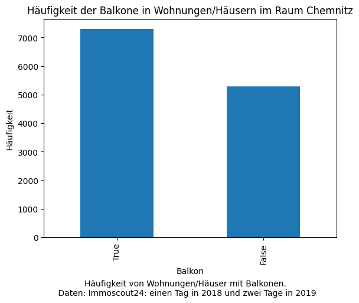

```python
balcony = chemnitz_2['balcony'].value_counts()

balcony.plot(kind='bar')
plt.title('Häufigkeit der Balkone in Wohnungen/Häusern im Raum Chemnitz')
plt.xlabel('Balkon')
plt.ylabel('Häufigkeit')

plt.figtext(0.5, -0.1, 'Häufigkeit von Wohnungen/Häuser mit Balkonen.\n Daten: Immoscout24: einen Tag in 2018 und zwei Tage in 2019', ha='center', va='bottom')
plt.show()
```

```python
# Anteil der Wohnuungen/Häuser mit Balkonen
total_count = len(chemnitz_2)
balcony_count = chemnitz_2['balcony'].sum()
percentage_with_balcony = (balcony_count / total_count) * 100
print(f"Der Anteil von Wohnungen/Häusern mit Balkonen beträgt {percentage_with_balcony:.2f}%.")
```

```
Der Anteil von Wohnungen/Häusern mit Balkonen beträgt 57.99%.
```

```python
# Kontrolle des Datensatzes
chemnitz_2.shape
```

```
(12575, 17)
```

#### 2.3 Numerische Spalten

##### Boxplot

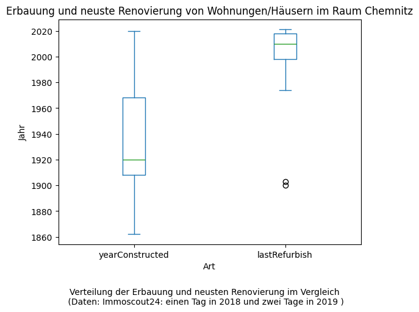

```python
construction_site = ["yearConstructed", "lastRefurbish"]
chemnitz_2[construction_site].plot(kind="box")

plt.title('Erbauung und neuste Renovierung von Wohnungen/Häusern im Raum Chemnitz')
plt.xlabel('Art')
plt.ylabel('Jahr')

plt.figtext(0.5, -0.1, 'Verteilung der Erbauung und neusten Renovierung im Vergleich\n (Daten: Immoscout24: einen Tag in 2018 und zwei Tage in 2019 )', ha='center', va='bottom')
plt.show()
```

```python
quantile_25_construction_year = chemnitz_2["yearConstructed"].quantile(0.25)
quantile_75_construction_year = chemnitz_2["yearConstructed"].quantile(0.75)
quantile_25_last_refurbish = chemnitz_2["lastRefurbish"].quantile(0.25)
quantile_75_last_refurbish = chemnitz_2["lastRefurbish"].quantile(0.75)

print(f"Das 0,25-Quantil (Q1) des Baujahres beträgt: {quantile_25_construction_year}")
print(f"Das 0,75-Quantil (Q3) des Baujahres beträgt: {quantile_75_construction_year}")

print(f"Das 0,75-Quantil (Q3) der letzten Renovierung beträgt: {quantile_75_last_refurbish}")
print(f"Das 0,25-Quantil (Q1) der letzten Renovierung beträgt: {quantile_25_last_refurbish}")
```

```
Das 0,25-Quantil (Q1) des Baujahres beträgt: 1908.0
Das 0,75-Quantil (Q3) des Baujahres beträgt: 1968.0
Das 0,75-Quantil (Q3) der letzten Renovierung beträgt: 2018.0
Das 0,25-Quantil (Q1) der letzten Renovierung beträgt: 1998.0
```

```python
count_thermal_char_more_than_1000 = chemnitz_2.loc[(chemnitz_2['thermalChar'] > 1000)]
count_thermal_char_more_than_1000["thermalChar"].count()
print("Es gibt insgesamt 7 Einträge bei denen der ThermalChar über 1000 beträgt -> sehr große Ausreißer.")
print("Diese werden rausgelöscht")
```

```
Es gibt insgesamt 7 Einträge bei denen der ThermalChar über 1000 beträgt -> sehr große Ausreißer.
Diese werden rausgelöscht
```

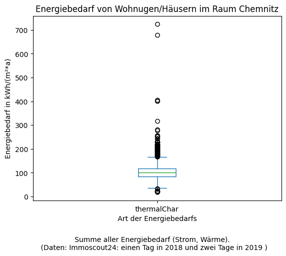

```python
chemnitz_2 = chemnitz_2.loc[(chemnitz_2['thermalChar'] <= 1000) | (chemnitz_2['thermalChar'].isna())]
chemnitz_2["thermalChar"].plot(kind="box")

plt.title('Energiebedarf von Wohnugen/Häusern im Raum Chemnitz')
plt.xlabel('Art der Energiebedarfs')
plt.ylabel('Energiebedarf in kWh/(m²*a)')

plt.figtext(0.5, -0.1, 'Summe aller Energiebedarf (Strom, Wärme). \n (Daten: Immoscout24: einen Tag in 2018 und zwei Tage in 2019 )', ha='center', va='bottom')
plt.show()
```

```python
count_rooms_more_then_10 = chemnitz_2.loc[(chemnitz_2['noRooms'] > 10)]
count_rooms_more_then_10["noRooms"].count()
print("Es gibt insgesamt 1 Eintrag, welches über 10 Räume besitzt -> signifikanter Ausreißer.")
print("Dieser wird rausgelöscht")
print("Genauso für über 1000 qm².")
```

```
Es gibt insgesamt 1 Eintrag, welches über 10 Räume besitzt -> signifikanter Ausreißer.
Dieser wird rausgelöscht
Genauso für über 1000 qm².
```

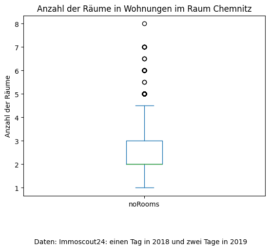

```python
# Entfernen von Wohnugen/Häusern mit mehr als 10 Räumen.
# In der Regel haben Wohnungen/Häuser nicht mehr als 100 Räume
# Ausnahme ist beispielsweise das Schloss Schönbrunn mit 1.441 Räumen (Google)
chemnitz_2 = chemnitz_2.loc[(chemnitz_2['noRooms'] <= 10) | (chemnitz_2['noRooms'].isna())]
chemnitz_2["noRooms"].plot(kind="box")

plt.title('Anzahl der Räume in Wohnungen im Raum Chemnitz')
plt.ylabel('Anzahl der Räume')

plt.figtext(0.5, -0.1, 'Daten: Immoscout24: einen Tag in 2018 und zwei Tage in 2019', ha='center', va='bottom')
plt.show()
```

```python
count_living_space_more_than_1000 = chemnitz_2.loc[(chemnitz_2['livingSpace'] > 1000)]
count_living_space_more_than_1000["livingSpace"].count()
```

```
1
```

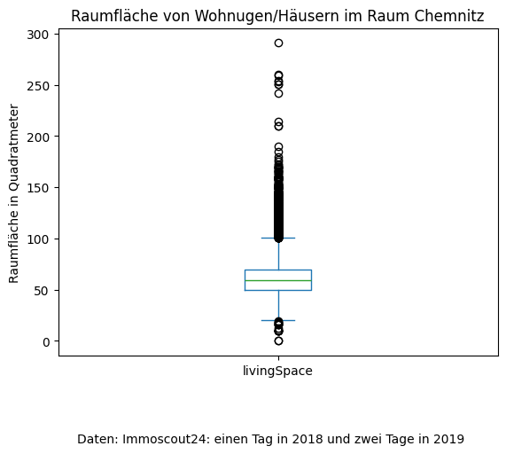

```python
chemnitz_2 = chemnitz_2.loc[(chemnitz_2['livingSpace'] <= 1000) | (chemnitz_2['livingSpace'].isna())]
chemnitz_2["livingSpace"].plot(kind="box")

plt.title('Raumfläche von Wohnugen/Häusern im Raum Chemnitz')
plt.ylabel('Raumfläche in Quadratmeter')

plt.figtext(0.5, -0.1, 'Daten: Immoscout24: einen Tag in 2018 und zwei Tage in 2019', ha='center', va='bottom')
plt.show()
```

```python
# Kontrolle des Datensatzes
chemnitz_2.shape
```

```
(12566, 17)
```

##### Histogramme

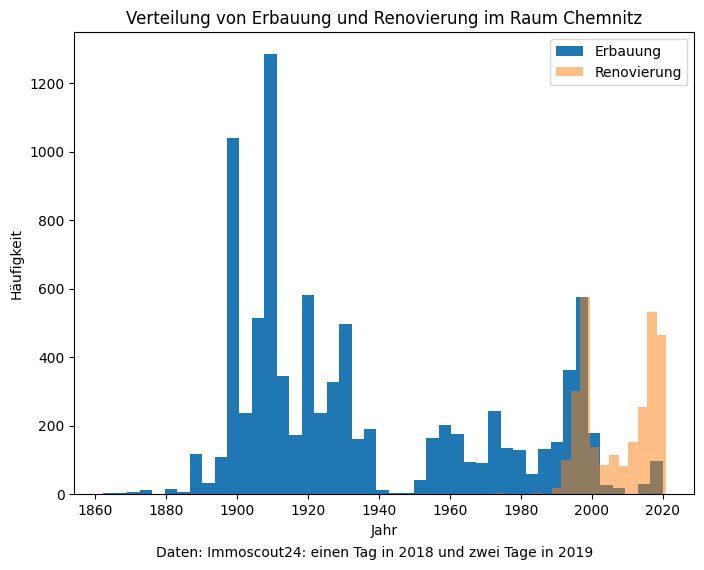

```python
plt.figure(figsize=(8, 6))

plt.hist(chemnitz_2["yearConstructed"], bins=45, label='Erbauung')

plt.hist(chemnitz_2["lastRefurbish"], bins=45, alpha=0.5, label='Renovierung')

plt.title('Verteilung von Erbauung und Renovierung im Raum Chemnitz')
plt.xlabel('Jahr')
plt.ylabel('Häufigkeit')
plt.legend()
plt.figtext(0.5, 0, 'Daten: Immoscout24: einen Tag in 2018 und zwei Tage in 2019', ha='center', va='bottom')

plt.show()
```

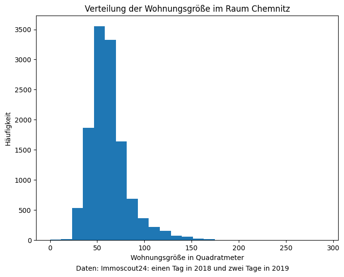

```python
plt.figure(figsize=(8, 6))

plt.hist(chemnitz_2["livingSpace"], bins=25)

plt.title('Verteilung der Wohnungsgröße im Raum Chemnitz')
plt.xlabel('Wohnungsgröße in Quadratmeter')
plt.ylabel('Häufigkeit')
plt.figtext(0.5, 0, 'Daten: Immoscout24: einen Tag in 2018 und zwei Tage in 2019', ha='center', va='bottom')

plt.show()
```

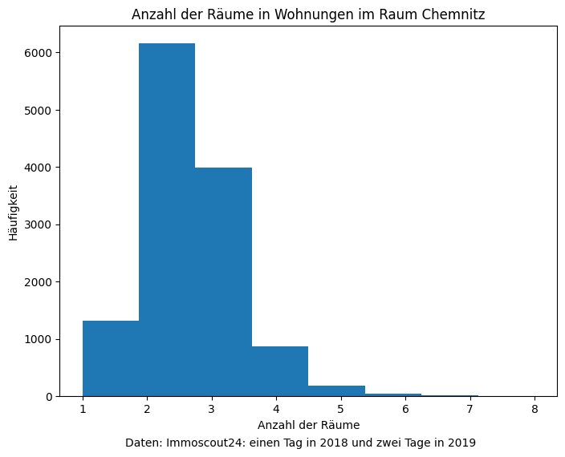

```python
plt.figure(figsize=(8, 6))

plt.hist(chemnitz_2["noRooms"], bins=8)

plt.title('Anzahl der Räume in Wohnungen im Raum Chemnitz')
plt.xlabel('Anzahl der Räume')
plt.ylabel('Häufigkeit')
plt.figtext(0.5, 0, 'Daten: Immoscout24: einen Tag in 2018 und zwei Tage in 2019', ha='center', va='bottom')

plt.show()
```

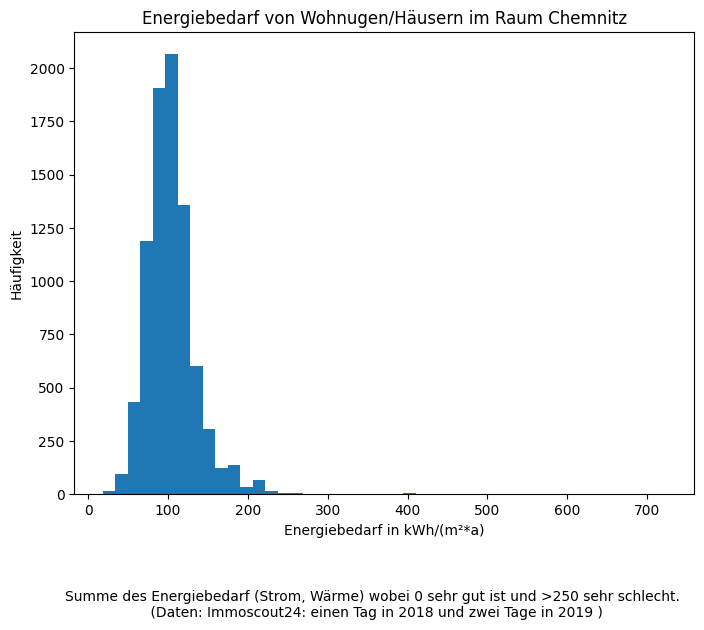

```python
plt.figure(figsize=(8, 6))

plt.hist(chemnitz_2["thermalChar"], bins=45)

plt.title('Energiebedarf von Wohnugen/Häusern im Raum Chemnitz')
plt.xlabel('Energiebedarf in kWh/(m²*a)')
plt.ylabel('Häufigkeit')
plt.figtext(0.5, -0.1, 'Summe des Energiebedarf (Strom, Wärme) wobei 0 sehr gut ist und >250 sehr schlecht. \n (Daten: Immoscout24: einen Tag in 2018 und zwei Tage in 2019 )', ha='center', va='bottom')
plt.show()
```

```python
# Kontrolle des Datensatzes
chemnitz_2.shape
```

```
(12566, 17)
```

##### Scatter

[output not shown]

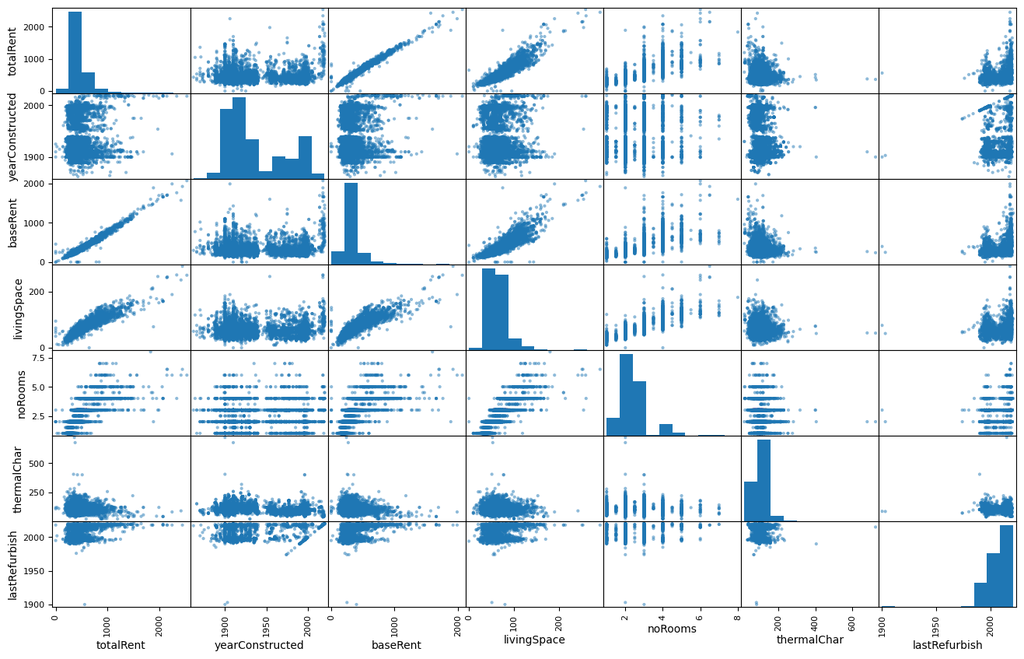

```python
columnsWithNumbers = ['totalRent', 'yearConstructed', 'baseRent', 'livingSpace', 'noRooms', 'thermalChar', 'lastRefurbish']
pd.plotting.scatter_matrix(chemnitz_2[columnsWithNumbers], figsize=(16,10))
```

```python
# Kontrolle des Datensatzes
chemnitz_2.shape
```

```
(12566, 17)
```

##### Heatmap

```python
import seaborn as sns
```

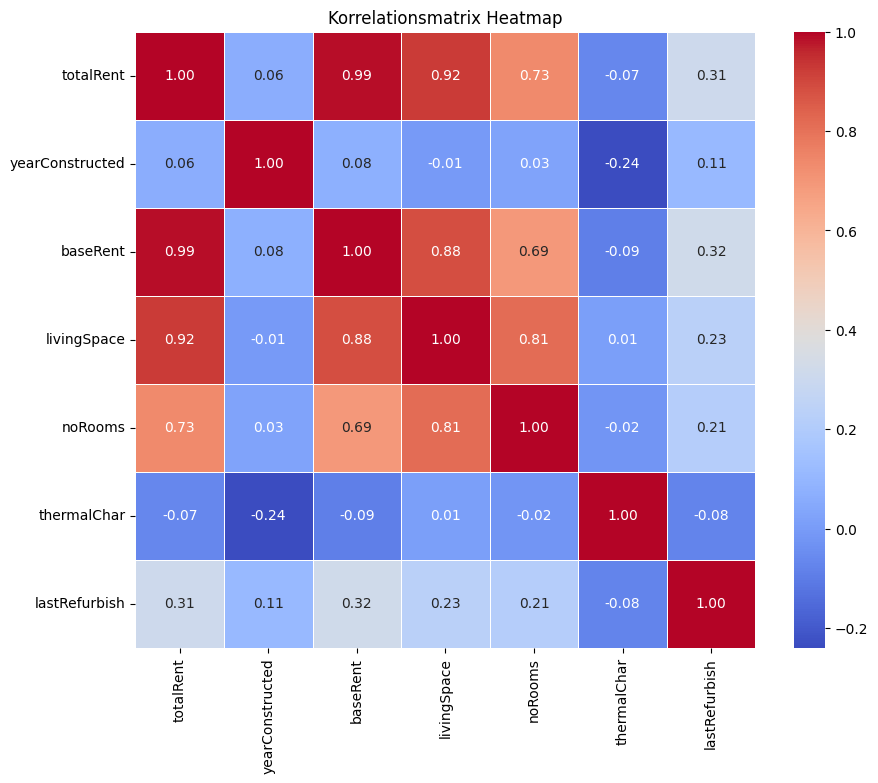

```python
correlation_matrix = chemnitz_2[columnsWithNumbers].corr()

plt.figure(figsize=(10, 8))
sns.heatmap(correlation_matrix, annot=True, cmap='coolwarm', fmt=".2f", linewidths=.5)
plt.title('Korrelationsmatrix Heatmap')
plt.show()
```

Die Korrelationsmatrix zeigt starke Zusammenhänge zwischen:

- Gesamtmiete und Grundmiete
- Gesamtmiete und Grundfläche
- Gesamtmiete und Anzahl der Räume (schwächer)

Kein Zusammenhang zu Angaben wie:

- Energiekosten und Baujahr/letze Renovierung

```python
# Kontrolle des Datensatzes
chemnitz_2.shape
```

```
(12566, 17)
```

```python
# Immobilien die Älter als 40 Jahre sind und nicht renoviert wurden.
apparmtents_older_40_years = chemnitz_2[(chemnitz_2["yearConstructed"] <= (chemnitz_2["yearConstructed"].max() - 40)) & (chemnitz_2["lastRefurbish"].isnull())]

apparmtents_older_40_years_count = len(apparmtents_older_40_years)
yearConstructed_count = len(chemnitz_2['yearConstructed'])
percentage_apartments_older_40_years = (apparmtents_older_40_years_count / yearConstructed_count) * 100
print(f"Wohnungen älter 40 Jahre ohne Renovierungen {percentage_apartments_older_40_years:.2f}%, insgesamt {apparmtents_older_40_years_count} Wohnungen.")
```

```
Wohnungen älter 40 Jahre ohne Renovierungen 41.35%, insgesamt 5196 Wohnungen.
```

```python
# Immobilien die vor 10 Jahren das letzte mal Renoviert wurden sind.
apparmtents_latest_renovation_10_years = chemnitz_2[(chemnitz_2["lastRefurbish"] <= (chemnitz_2["lastRefurbish"].max() - 10))]

apparmtents_latest_renovation_10_years_count = len(apparmtents_latest_renovation_10_years)
lastRefurbish_count = len(chemnitz_2['lastRefurbish'])
percentage_apparmtents_latest_renovation_10_years = (apparmtents_latest_renovation_10_years_count / lastRefurbish_count) * 100
print(f"Wohnungen die zuletzt vor 10 Jahren renoviert wurden sind: {percentage_apparmtents_latest_renovation_10_years:.2f}%, insgeamt {apparmtents_latest_renovation_10_years_count} Wohnungen.")
```

```
Wohnungen die zuletzt vor 10 Jahren renoviert wurden sind: 11.64%, insgeamt 1463 Wohnungen.
```

```python
# Anteil der Wohnuungen/Häuser die Älter als 40 Jahre sind und nicht Renoviert wurden sind mit Balkonen
total_count = len(apparmtents_older_40_years)
balcony_count = apparmtents_older_40_years['balcony'].sum()
percentage_with_balcony = (balcony_count / total_count) * 100
print(f"Anteil der Wohnungen/Häuser die Älter als 40 Jahre sind und nicht Renoviert wurden sind mit Balkonen beträgt {percentage_with_balcony:.2f}%, insgesamt {balcony_count} Stück.")
```

```
Anteil der Wohnungen/Häuser die Älter als 40 Jahre sind und nicht Renoviert wurden sind mit Balkonen beträgt 57.62%, insgesamt 2994 Stück.
```

```python
# Anteil der Wohnuungen/Häuser die Älter als 40 Jahre sind und nicht Renoviert wurden sind mit Balkonen
total_count = len(apparmtents_latest_renovation_10_years)
balcony_count = apparmtents_latest_renovation_10_years['balcony'].sum()
percentage_with_balcony = (balcony_count / total_count) * 100
print(f"Wohnungen die zuletzt vor 10 Jahren renoviert wurden mit Balkonen beträgt {percentage_with_balcony:.2f}%, insgesamt {balcony_count} Stück.")
```

```
Wohnungen die zuletzt vor 10 Jahren renoviert wurden mit Balkonen beträgt 56.12%, insgesamt 821 Stück.
```

```python
wohnungen_2_3_raeume = apparmtents_older_40_years[(apparmtents_older_40_years['noRooms'] >= 2) & (apparmtents_older_40_years['noRooms'] <= 3)]

anzahl_wohnungen_2_3_raeume = wohnungen_2_3_raeume.shape[0]

print(f"Die Anzahl der Wohnungen mit 2 und 3 Räumen, welche älter als 40 Jahre sind, beträgt: {anzahl_wohnungen_2_3_raeume}")
```

```
Die Anzahl der Wohnungen mit 2 und 3 Räumen, welche älter als 40 Jahre sind, beträgt: 4309
```

```python
wohnungen_2_3_raeume = apparmtents_latest_renovation_10_years[(apparmtents_latest_renovation_10_years['noRooms'] >= 2) & (apparmtents_latest_renovation_10_years['noRooms'] <= 3)]

anzahl_wohnungen_2_3_raeume = wohnungen_2_3_raeume.shape[0]

print(f"Die Anzahl der Wohnungen mit 2 und 3 Räumen, welche das letzte Mal vor über 10 Jahren renoviert worden sind, beträgt: {anzahl_wohnungen_2_3_raeume}")
```

```
Die Anzahl der Wohnungen mit 2 und 3 Räumen, welche das letzte Mal vor über 10 Jahren renoviert worden sind, beträgt: 1201
```

```python
saveToCsv(chemnitz_2, "chemnitzWO")
```

### Erkenntnisse Data Exploration

Entfernen von Wohnungen/Häusern:

- mit mehr als 10 Räumen (1x)
- mehr als 1000 qm (1x)
- mit Energiebedarf größer 1000 kWh/(m²*a) (7x)

Aufällig:

Zusammenhang zu Aufgabe 1:

- 41.35 % (5196 Wohnungen) der Wohnungen sind Älter als 40 Jahre und nicht renoviert => Es fallen Umfassende Renovierungen an. Haben diese Wohnungen einen Balkon oder Außenbereich (Fokus auf Spezialisierung im Außenbereich)?
- 57.62 % dieser Wohungen haben einen Balkon, 2994 Wohnungen ---2
- 11.64 % (1463 Wohnungen) der Wohnungen die renoviert wurden, wurden höchsten vor 10 Jahren Renovierungsarbeiten durchgeführt => Kleine Sanierungen
- 56.12 % dieser Wohnungen haben einen Balkon, 821 Wohnungen

Insgesamt also 3815 Wohnungen von insgesamt renovierungsbedürftigen 6659 Wohnungen.

### 3. Data Preparation

Bereits entfernte Ausreißer (Erkenntnis aus Aufgabe 2.3):

- mit mehr als 10 Räumen (1x)
- mehr als 1000 qm (1x)
- mit Energiebedarf größer 1000 kWh/(m²*a) (7x)

- Preis pro Quadratmeter errechnen -> Unseriöse Angebote, die weit unter dem Niedrigpreis liegen entfernen
- NaN Werte durch Durchschnitt ersetzen
- Bei nicht vorhandener TotalRent diese durch die BaseRent ersetzen
- Bei nicht vorhandener TotalRent und BaseRent Eintrag löschen

#### 3.1 Daten bereinigen

```python
chemnitz_3 = pd.read_csv("./chemnitzWO.csv", sep="\t")
chemnitz_3.head(5)
print(chemnitz_3.shape)
```

```
(12566, 17)
```

```python
chemnitz_3["balcony"] = chemnitz_3["balcony"].fillna(False)
chemnitz_3["balcony"] = chemnitz_3["balcony"].astype(bool)
print(chemnitz_3.shape)
```

```
(12566, 17)
```

```python
# Lösche Einträge, wo sowohl 'totalRent' und 'baseRent' 0.0 oder NaN sind
chemnitz_3 = chemnitz_3[~((chemnitz_3['totalRent'].isnull() | (chemnitz_3['totalRent'] == 0.0)) &
                                    (chemnitz_3['baseRent'].isnull() | (chemnitz_3['baseRent'] == 0.0)))]

# Display the filtered DataFrame
chemnitz_3.shape
```

```
(12563, 17)
```

```python
# totalRent besitzt NaN Werte
# NaN und 0.0 ersetzen durch baseRent
nan_count = chemnitz_3["totalRent"].isna().sum()
zero_count = (chemnitz_3["totalRent"] == 0.0).sum()
print("Number of NaN values in 'totalRent':", nan_count)
print("Number of 0.0 values in 'totalRent':", zero_count)

chemnitz_3["totalRent"].fillna(chemnitz_3["baseRent"], inplace=True)
chemnitz_3.loc[chemnitz_3['totalRent'] == 0.0, 'totalRent'] = chemnitz_3.loc[chemnitz_3['totalRent'] == 0.0, 'baseRent']

nan_count = chemnitz_3["totalRent"].isna().sum()
zero_count = (chemnitz_3["totalRent"] == 0.0).sum()
print("Nonexistent totalRent has been replaced by baseRent.")
print("Number of NaN values in 'totalRent':", nan_count)
print("Number of 0.0 values in 'totalRent':", zero_count)


# baseRent besitzt NaN Werte
# NaN und 0.0 ersetzen durch baseRent
nan_count = chemnitz_3["baseRent"].isna().sum()
zero_count = (chemnitz_3["baseRent"] == 0.0).sum()
print("Number of NaN values in 'baseRent':", nan_count)
print("Number of 0.0 values in 'baseRent':", zero_count)

chemnitz_3["baseRent"].fillna(chemnitz_3["totalRent"], inplace=True)
chemnitz_3.loc[chemnitz_3['baseRent'] == 0.0, 'baseRent'] = chemnitz_3.loc[chemnitz_3['baseRent'] == 0.0, 'totalRent']

nan_count = chemnitz_3["baseRent"].isna().sum()
zero_count = (chemnitz_3["baseRent"] == 0.0).sum()
print("Nonexistent baseRent has been replaced by totalRent.")
print("Number of NaN values in 'baseRent':", nan_count)
print("Number of 0.0 values in 'baseRent':", zero_count)

# Einmal ist totalrent kleiner als baserent, hier ebenfalls durch baserent ersetzen
rent_discrepancy_indices = chemnitz_3['totalRent'] < chemnitz_3['baseRent']
chemnitz_3.loc[rent_discrepancy_indices, 'totalRent'] = chemnitz_3.loc[rent_discrepancy_indices, 'baseRent']

sorted_chemnitz_3 = chemnitz_3.sort_values(by='totalRent', ascending=True)
sorted_chemnitz_3.head(5)
```

```
Number of NaN values in 'totalRent': 1184
Number of 0.0 values in 'totalRent': 2
Nonexistent totalRent has been replaced by baseRent.
Number of NaN values in 'totalRent': 0
Number of 0.0 values in 'totalRent': 0
Number of NaN values in 'baseRent': 0
Number of 0.0 values in 'baseRent': 2
Nonexistent baseRent has been replaced by totalRent.
Number of NaN values in 'baseRent': 0
Number of 0.0 values in 'baseRent': 0
```

|  | regio1 | newlyConst | balcony | totalRent | yearConstructed | hasKitchen | baseRent | livingSpace | condition | interiorQual | petsAllowed | noRooms | thermalChar | regio2 | regio3 | lastRefurbish | date |
| --- | --- | --- | --- | --- | --- | --- | --- | --- | --- | --- | --- | --- | --- | --- | --- | --- | --- |
| 629 | Sachsen | False | False | 25.00 | 1920.0 | False | 25.00 | 12.50 | mint_condition | NaN | no | 1.0 | 117.9 | Chemnitz | Schloßchemnitz | 2002.0 | Oct19 |
| 4613 | Sachsen | False | False | 60.50 | NaN | False | 38.50 | 11.00 | refurbished | NaN | no | 1.0 | 107.7 | Chemnitz | Schloßchemnitz | NaN | Feb20 |
| 7665 | Sachsen | False | True | 104.29 | 1972.0 | False | 104.29 | 31.04 | NaN | NaN | negotiable | 1.0 | 86.0 | Chemnitz | Yorckgebiet | NaN | Oct19 |
| 4594 | Sachsen | False | False | 119.00 | 1959.0 | True | 119.00 | 10.00 | fully_renovated | NaN | negotiable | 1.0 | 75.0 | Chemnitz | Bernsdorf | NaN | Sep18 |
| 7995 | Sachsen | False | False | 119.00 | 1961.0 | True | 119.00 | 10.00 | fully_renovated | NaN | negotiable | 1.0 | 67.0 | Chemnitz | Bernsdorf | NaN | May19 |

```python
# yearConstructed besitzt NaN Werte
# NaN ersetzen durch Durchschnitt
nan_count = chemnitz_3["yearConstructed"].isna().sum()
zero_count = (chemnitz_3["yearConstructed"] == 0.0).sum()
print("Number of NaN values in 'yearConstructed':", nan_count)
print("Number of 0.0 values in 'yearConstructed':", zero_count)
average_year_constructed_mean = chemnitz_3['yearConstructed'].mean()
chemnitz_3["yearConstructed"] = chemnitz_3["yearConstructed"].fillna(average_year_constructed_mean)
chemnitz_3["yearConstructed"] = chemnitz_3["yearConstructed"].astype(int)
```

```
Number of NaN values in 'yearConstructed': 3760
Number of 0.0 values in 'yearConstructed': 0
```

```python
# livingSpace besitzt NaN Werte
nan_count = chemnitz_3["livingSpace"].isna().sum()
zero_count = (chemnitz_3["livingSpace"] == 0.0).sum()
print("Number of NaN values in 'livingSpace':", nan_count)
print("Number of 0.0 values in 'livingSpace':", zero_count)
chemnitz_3 = chemnitz_3[chemnitz_3["livingSpace"] != 0.0]
zero_count = (chemnitz_3["livingSpace"] == 0.0).sum()
print("Number of 0.0 values in 'livingSpace' after change:", zero_count)
#living_space_mean = chemnitz_3['livingSpace'].mean()
#living_space_with_dates = chemnitz_3[chemnitz_3['livingSpace'].astype(str).str.contains('\d{2}\.\d{2}\.\d{4}', na=False)]
#chemnitz_3.loc[living_space_with_dates.index, 'livingSpace'] = living_space_mean.round(2)
```

```
Number of NaN values in 'livingSpace': 0
Number of 0.0 values in 'livingSpace': 1
Number of 0.0 values in 'livingSpace' after change: 0
```

```python
# condition besitzt NaN Werte
# NaN ersetzen durch "unkown"
nan_count = chemnitz_3["condition"].isna().sum()
print("Number of NaN values in 'condition':", nan_count)
chemnitz_3["condition"] = chemnitz_3["condition"].fillna("unkown")
chemnitz_3["condition"].unique()
```

```
Number of NaN values in 'condition': 2762
```

```
array(['unkown', 'fully_renovated', 'well_kept', 'refurbished',
       'need_of_renovation', 'first_time_use', 'mint_condition',
       'modernized', 'first_time_use_after_refurbishment', 'negotiable'],
      dtype=object)
```

```python
# interiorQual besitzt NaN Werte
# NaN ersetzen durch "unkown"
nan_count = chemnitz_3["interiorQual"].isna().sum()
print("Number of NaN values in 'interiorQual':", nan_count)
chemnitz_3["interiorQual"] = chemnitz_3["interiorQual"].fillna("unkown")
chemnitz_3["interiorQual"].unique()
```

```
Number of NaN values in 'interiorQual': 5490
```

```
array(['normal', 'unkown', 'sophisticated', 'luxury', 'simple'],
      dtype=object)
```

```python
# Alle NaN Werte bei petsAllowed Werte zu false setzen.
nan_count = chemnitz_3["petsAllowed"].isna().sum()
print("Number of NaN values in 'petsAllowed':", nan_count)
chemnitz_3['petsAllowed'] = chemnitz_3['petsAllowed'].fillna("no")
chemnitz_3["petsAllowed"].unique()
```

```
Number of NaN values in 'petsAllowed': 4263
```

```
array(['no', 'yes', 'negotiable'], dtype=object)
```

```python
# noRooms besitzt Werte im Format eines Datums
nan_count = chemnitz_3["noRooms"].isna().sum()
zero_count = (chemnitz_3["noRooms"] == 0.0).sum()
print("Number of NaN values in 'noRooms':", nan_count)
print("Number of 0.0 values in 'noRooms':", zero_count)
#no_rooms_with_dates = chemnitz_3[chemnitz_3['noRooms'].astype(str).str.contains('\d{2}\.\d{2}\.\d{4}', na=False)]
#chemnitz_3.loc[no_rooms_with_dates.index, 'noRooms'] = 2
```

```
Number of NaN values in 'noRooms': 0
Number of 0.0 values in 'noRooms': 0
```

```python
# regio3
# Beim export/import in eine csv hatte das ß Probleme
chemnitz_3['regio3'] = chemnitz_3['regio3'].str.replace('ß', 'ss')
```

```python
# lastRefurbish
# NaN Werte mit Erbauungsdatum ersetzen
nan_count = chemnitz_3["lastRefurbish"].isna().sum()
print("Number of NaN values in 'lastRefurbish':", nan_count)
chemnitz_3['lastRefurbish'] = chemnitz_3['lastRefurbish'].combine_first(chemnitz_3['yearConstructed'])
chemnitz_3["lastRefurbish"] = chemnitz_3["lastRefurbish"].astype(int)
```

```
Number of NaN values in 'lastRefurbish': 9741
```

```python
# date
# Spalte entfernen, da unbekannt in welchem Jahr
chemnitz_3.drop(columns=['date'], inplace=True)
```

```python
# Bundesland kann aus Chemnitz hergeleitet werden
chemnitz_3.drop(columns=['regio1'], inplace=True)
```

```python
#saveToCsv(chemnitz_3, "chemnitz_cleaned_but_not_thermalChar")
```

```python
# thermalChar besitzt NaN Werte
# NaN ersetzen durch Durchschnitt
# verfälscht die Vorhersage
nan_count = chemnitz_3["thermalChar"].isna().sum()
print("Number of NaN values in 'thermalChar':", nan_count)

#chemnitz_3.dropna(subset=['thermalChar'], inplace=True)

thermal_char_mean = chemnitz_3['thermalChar'].mean()
chemnitz_3["thermalChar"] = chemnitz_3["thermalChar"].fillna(thermal_char_mean.round(2))

nan_count_after_drop = chemnitz_3["thermalChar"].isna().sum()
print("Number of NaN values in 'thermalChar' after change:", nan_count_after_drop)
```

```
Number of NaN values in 'thermalChar': 4220
Number of NaN values in 'thermalChar' after change: 0
```

```python
# Price per sqm ausrechnen
# Ein Wert unter 2,5€/m², dieser wird gelöscht
chemnitz_3['price_per_sqm'] = (chemnitz_3['totalRent'] / chemnitz_3['livingSpace']).round(2)

sorted_chemnitz_3 = chemnitz_3.sort_values(by='price_per_sqm', ascending=True)
sorted_chemnitz_3.head(5)

below_2_5_count = (chemnitz_3['price_per_sqm'] < 2.5).sum()
print(f"Anzahl der Objekte mit einem Preis unter 2,50€/m²: {below_2_5_count}.")

chemnitz_3 = chemnitz_3[chemnitz_3['price_per_sqm'] >= 2.5]

chemnitz_3.shape
```

```
Anzahl der Objekte mit einem Preis unter 2,50€/m²: 1.
```

```
(12561, 16)
```

```python
saveToCsv(chemnitz_3, "chemnitz_cleaned")
chemnitz_3.head(10)
```

|  | newlyConst | balcony | totalRent | yearConstructed | hasKitchen | baseRent | livingSpace | condition | interiorQual | petsAllowed | noRooms | thermalChar | regio2 | regio3 | lastRefurbish | price_per_sqm |
| --- | --- | --- | --- | --- | --- | --- | --- | --- | --- | --- | --- | --- | --- | --- | --- | --- |
| 0 | False | True | 307.00 | 1930 | False | 219.00 | 40.20 | unkown | normal | no | 2.0 | 123.00 | Chemnitz | Sonnenberg | 1930 | 7.64 |
| 1 | False | True | 501.00 | 1935 | False | 340.00 | 65.00 | fully_renovated | normal | yes | 3.0 | 103.47 | Chemnitz | Lutherviertel | 1935 | 7.71 |
| 2 | False | True | 425.00 | 1909 | True | 280.00 | 53.12 | well_kept | normal | negotiable | 2.0 | 153.00 | Chemnitz | Bernsdorf | 2014 | 8.00 |
| 3 | False | True | 760.00 | 1998 | True | 560.00 | 115.00 | unkown | unkown | no | 5.0 | 103.47 | Chemnitz | Sonnenberg | 2000 | 6.61 |
| 4 | False | False | 715.00 | 1920 | False | 515.00 | 102.30 | well_kept | unkown | no | 3.0 | 103.47 | Chemnitz | Zentrum | 1995 | 6.99 |
| 5 | False | False | 260.00 | 1900 | False | 170.00 | 41.19 | refurbished | normal | no | 1.5 | 82.00 | Chemnitz | Altchemnitz | 1900 | 6.31 |
| 6 | False | False | 397.00 | 1935 | True | 276.00 | 55.00 | fully_renovated | unkown | yes | 2.0 | 103.47 | Chemnitz | Bernsdorf | 1935 | 7.22 |
| 7 | False | False | 282.00 | 1998 | False | 200.00 | 43.17 | unkown | unkown | no | 2.0 | 57.20 | Chemnitz | Hilbersdorf | 1998 | 6.53 |
| 8 | False | True | 906.11 | 1880 | False | 697.81 | 104.15 | unkown | unkown | no | 4.0 | 68.00 | Chemnitz | Schlosschemnitz | 1880 | 8.70 |
| 9 | False | False | 289.00 | 1935 | False | 289.00 | 60.00 | need_of_renovation | unkown | negotiable | 2.0 | 103.47 | Chemnitz | Ebersdorf | 1935 | 4.82 |

```python
chemnitz_3.shape

# ÜBERPRÜFEN wieder 9 mehr als bei Aufgabe 2 (Schlosschemnitz wahrscheinlich wieder drin etc.)
```

```
(12561, 16)
```

#### 3.2 Feature Engineering

# Backward Feature Enginering zur Auswahl relevanter Attribute.

Daraus folgt:

- Wohnungen ohne Balkon entfernt werden.
- Wohnungen älter als 40 Jahre und nicht Renoviert umfassende Renovierungen sind notwendig.
- Wohnungen die vor 10 Jahren die letzte Renovierung kleine Sanierungen sind notwendig.

Vorhersage: Mit wieviel Umsatz ist zu rechnen?

Anmerkung: Testen und Ergebnisse betrachten.

Auswahl der Features:

- Erbauungsjahr
- Letzte Renovierung
- Grundkosten und Gesamtkosten (geringe Kosten => schlechter Zustand der Wohnung)
- Balkon
- Wohnfläche (größere Wohnungen haben i.R. einen Außenbereich)
- Anzahl der Räume
- Energiebedarf (schlecht => Reonvierungsbedürftig)
- Condition
- Interior Quality

```python
chemnitz_apartments_32 = pd.read_csv('./chemnitz_cleaned.csv', sep="\t")
chemnitz_apartments_32.head(5)
chemnitz_apartments_32.shape
```

```
(12561, 16)
```

```python
# Daten vorbereiten für Lasso-Regresssion
chemnitz_apartments_32.loc[:, "balcony"] = chemnitz_apartments_32["balcony"].astype(int)
chemnitz_apartments_32.loc[:, "hasKitchen"] = chemnitz_apartments_32["hasKitchen"].astype(int)
chemnitz_apartments_32.loc[:, "newlyConst"] = chemnitz_apartments_32["newlyConst"].astype(int)
# Entfernen von unwichtigen Features
chemnitz_apartments_32 = chemnitz_apartments_32.drop("regio2", axis=1)
chemnitz_apartments_32 = chemnitz_apartments_32.drop("regio3", axis=1)
chemnitz_apartments_32.head(5)
# Define mapping dictionaries for condition and interiorQual
pets_allowed_mapping= {
    'no': 0,
    'negotiable':0.5,
    'yes': 1
}
condition_mapping = {
    'unkown': 0,
    'fully_renovated': 1,
    'well_kept': 0.8,
    'refurbished': 0.9,
    'need_of_renovation': 0.2,
    'first_time_use': 1,
    'mint_condition': 1,
    'modernized': 0.9,
    'first_time_use_after_refurbishment': 1,
    'negotiable': 0.5
}

interior_qual_mapping = {
    'normal': 0.5,
    'unkown': 0,
    'sophisticated': 0.9,
    'luxury': 1,
    'simple': 0.2
}

# Replace categorical values with mapped values
chemnitz_apartments_32['petsAllowed'] = chemnitz_apartments_32['petsAllowed'].map(pets_allowed_mapping)
chemnitz_apartments_32['condition'] = chemnitz_apartments_32['condition'].map(condition_mapping)
chemnitz_apartments_32['interiorQual'] = chemnitz_apartments_32['interiorQual'].map(interior_qual_mapping)
```

```python
chemnitz_apartments_32.head(5)
```

|  | newlyConst | balcony | totalRent | yearConstructed | hasKitchen | baseRent | livingSpace | condition | interiorQual | petsAllowed | noRooms | thermalChar | lastRefurbish | price_per_sqm |
| --- | --- | --- | --- | --- | --- | --- | --- | --- | --- | --- | --- | --- | --- | --- |
| 0 | 0 | 1 | 307.0 | 1930 | 0 | 219.0 | 40.20 | 0.0 | 0.5 | 0.0 | 2.0 | 123.00 | 1930 | 7.64 |
| 1 | 0 | 1 | 501.0 | 1935 | 0 | 340.0 | 65.00 | 1.0 | 0.5 | 1.0 | 3.0 | 103.47 | 1935 | 7.71 |
| 2 | 0 | 1 | 425.0 | 1909 | 1 | 280.0 | 53.12 | 0.8 | 0.5 | 0.5 | 2.0 | 153.00 | 2014 | 8.00 |
| 3 | 0 | 1 | 760.0 | 1998 | 1 | 560.0 | 115.00 | 0.0 | 0.0 | 0.0 | 5.0 | 103.47 | 2000 | 6.61 |
| 4 | 0 | 0 | 715.0 | 1920 | 0 | 515.0 | 102.30 | 0.8 | 0.0 | 0.0 | 3.0 | 103.47 | 1995 | 6.99 |

```
Best Alpha for Lasso-Reg: 0.1
R-squared (R2) Score: 0.08034075092680015
Root Mean Squared Error (RMSE): 22.41055556401966
Mean Absolute Percentage Error (MAPE): 15.166083494259198
```

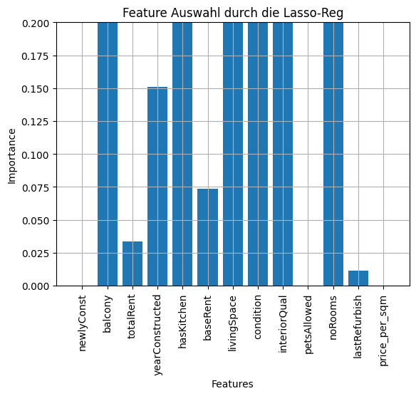

```python
# Lasso Regression, um ThermalChar vorherzusagen

from sklearn.linear_model import Lasso
from sklearn.model_selection import train_test_split
from sklearn.metrics import r2_score, mean_squared_error
import numpy as np
from sklearn.model_selection import GridSearchCV

target = "thermalChar"

X = chemnitz_apartments_32.drop(target, axis=1)
y = chemnitz_apartments_32[target]

X_train, X_test, y_train, y_test = train_test_split(X, y, test_size=0.20, random_state=42)

alphas = [0.0001, 0.001, 0.01, 0.1, 1, 10]
param_grid = {'alpha': alphas}
grid_search = GridSearchCV(Lasso(), param_grid, cv=5)
grid_search.fit(X_train, y_train)

best_alpha = grid_search.best_params_['alpha']
print("Best Alpha for Lasso-Reg:", best_alpha)

lasso_model = Lasso(alpha=best_alpha)
lasso_model.fit(X_train, y_train)

y_pred = lasso_model.predict(X_test)

r2 = r2_score(y_test, y_pred)
rmse = np.sqrt(mean_squared_error(y_test, y_pred))
mape = np.mean(np.abs((y_test - y_pred) / y_test)) * 100

# Output evaluation results
print("R-squared (R2) Score:", r2)
print("Root Mean Squared Error (RMSE):", rmse)
print("Mean Absolute Percentage Error (MAPE):", mape)

lasso1_coef = np.abs(lasso_model.coef_)

names=chemnitz_apartments_32.drop(target, axis=1).columns
plt.bar(names, lasso1_coef)
plt.xticks(rotation=90)
plt.grid()
plt.title("Feature Auswahl durch die Lasso-Reg")
plt.xlabel("Features")
plt.ylabel("Importance")
plt.ylim(0, 0.2)
plt.show()
```

```python
# Auswhal der Features mit einem Threshold
feature_subset=np.array(names)[lasso1_coef>0.025]
print("Selected Feature Columns: {}".format(feature_subset))

# Features mit targetvariable
feature_subset=np.append(feature_subset, target)
print("Selected Columns: {}".format(feature_subset))
```

```
Selected Feature Columns: ['balcony' 'totalRent' 'yearConstructed' 'hasKitchen' 'baseRent'
 'livingSpace' 'condition' 'interiorQual' 'noRooms']
Selected Columns: ['balcony' 'totalRent' 'yearConstructed' 'hasKitchen' 'baseRent'
 'livingSpace' 'condition' 'interiorQual' 'noRooms' 'thermalChar']
```

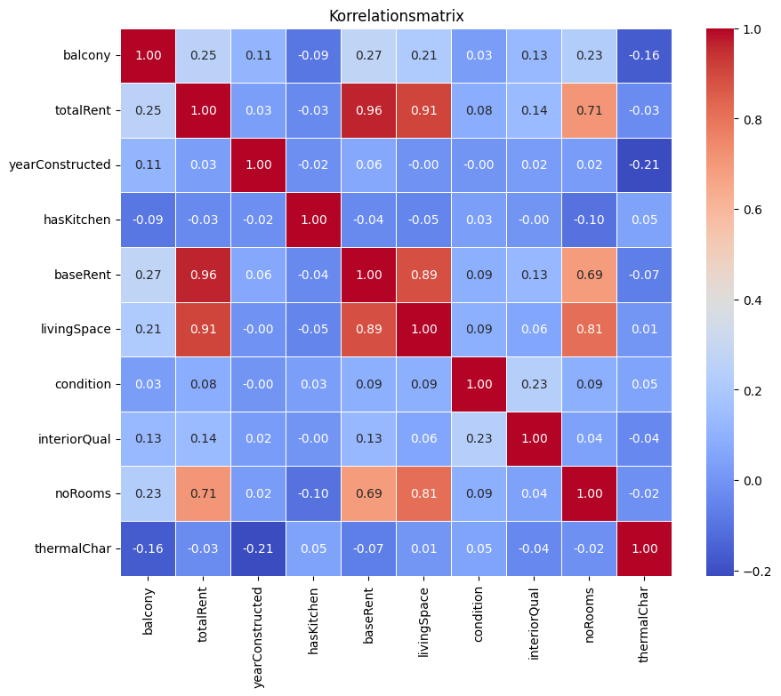

```python
import seaborn as sns
import matplotlib.pyplot as plt

# Erstellen der Korrelationsmatrix
chemnitz_corr = chemnitz_apartments_32[feature_subset]
correlation_matrix = chemnitz_corr.corr()

# Visualisierung der Korrelationsmatrix als Heatmap
plt.figure(figsize=(10, 8))
sns.heatmap(correlation_matrix, annot=True, cmap='coolwarm', fmt=".2f", linewidths=.5)
plt.title('Korrelationsmatrix')
plt.show()
```

ThermalChar bietet leider keine sinnvollen Korrelationen, Vorhersagen werden schwierig werden.

Das Ersetzen der Werte mit Durchschnittswerten führt zu schlechteren Vorhersagen aber später besseren Clustern.

## 4. Modeling und Evaluation

Gewählte Verfahren:

- Lineare Regression
- Random Forest Resgression
- SVM

### Prepare Data Regression Ready

```python
chemnitz_apartments_4 = pd.read_csv('./chemnitz_cleaned.csv', sep="\t")
chemnitz_apartments_4.shape
```

```
(12561, 16)
```

```python
chemnitz_apartments_4.head(5)
```

|  | newlyConst | balcony | totalRent | yearConstructed | hasKitchen | baseRent | livingSpace | condition | interiorQual | petsAllowed | noRooms | thermalChar | regio2 | regio3 | lastRefurbish | price_per_sqm |
| --- | --- | --- | --- | --- | --- | --- | --- | --- | --- | --- | --- | --- | --- | --- | --- | --- |
| 0 | False | True | 307.0 | 1930 | False | 219.0 | 40.20 | unkown | normal | no | 2.0 | 123.00 | Chemnitz | Sonnenberg | 1930 | 7.64 |
| 1 | False | True | 501.0 | 1935 | False | 340.0 | 65.00 | fully_renovated | normal | yes | 3.0 | 103.47 | Chemnitz | Lutherviertel | 1935 | 7.71 |
| 2 | False | True | 425.0 | 1909 | True | 280.0 | 53.12 | well_kept | normal | negotiable | 2.0 | 153.00 | Chemnitz | Bernsdorf | 2014 | 8.00 |
| 3 | False | True | 760.0 | 1998 | True | 560.0 | 115.00 | unkown | unkown | no | 5.0 | 103.47 | Chemnitz | Sonnenberg | 2000 | 6.61 |
| 4 | False | False | 715.0 | 1920 | False | 515.0 | 102.30 | well_kept | unkown | no | 3.0 | 103.47 | Chemnitz | Zentrum | 1995 | 6.99 |

```python
# Daten vorbereiten für Regresssion
chemnitz_apartments_4.loc[:, "balcony"] = chemnitz_apartments_4["balcony"].astype(int)
chemnitz_apartments_4.loc[:, "hasKitchen"] = chemnitz_apartments_4["hasKitchen"].astype(int)
chemnitz_apartments_4.loc[:, "newlyConst"] = chemnitz_apartments_4["newlyConst"].astype(int)
# Entfernen von unwichtigen Features
chemnitz_apartments_4 = chemnitz_apartments_4.drop("regio2", axis=1)
chemnitz_apartments_4 = chemnitz_apartments_4.drop("regio3", axis=1)
chemnitz_apartments_4.head(5)
# Bewertung der Values durch Zahlen von 0 - 1
pets_allowed_mapping= {
    'no': 0,
    'negotiable':0.5,
    'yes': 1
}
condition_mapping = {
    'unkown': 0,
    'fully_renovated': 1,
    'well_kept': 0.8,
    'refurbished': 0.9,
    'need_of_renovation': 0.2,
    'first_time_use': 1,
    'mint_condition': 1,
    'modernized': 0.9,
    'first_time_use_after_refurbishment': 1,
    'negotiable': 0.5
}

interior_qual_mapping = {
    'normal': 0.5,
    'unkown': 0,
    'sophisticated': 0.9,
    'luxury': 1,
    'simple': 0.2
}

# Replace categorical values with mapped values
chemnitz_apartments_4['petsAllowed'] = chemnitz_apartments_4['petsAllowed'].map(pets_allowed_mapping)
chemnitz_apartments_4['condition'] = chemnitz_apartments_4['condition'].map(condition_mapping)
chemnitz_apartments_4['interiorQual'] = chemnitz_apartments_4['interiorQual'].map(interior_qual_mapping)
```

```python
chemnitz_apartments_4.head(5)
```

|  | newlyConst | balcony | totalRent | yearConstructed | hasKitchen | baseRent | livingSpace | condition | interiorQual | petsAllowed | noRooms | thermalChar | lastRefurbish | price_per_sqm |
| --- | --- | --- | --- | --- | --- | --- | --- | --- | --- | --- | --- | --- | --- | --- |
| 0 | 0 | 1 | 307.0 | 1930 | 0 | 219.0 | 40.20 | 0.0 | 0.5 | 0.0 | 2.0 | 123.00 | 1930 | 7.64 |
| 1 | 0 | 1 | 501.0 | 1935 | 0 | 340.0 | 65.00 | 1.0 | 0.5 | 1.0 | 3.0 | 103.47 | 1935 | 7.71 |
| 2 | 0 | 1 | 425.0 | 1909 | 1 | 280.0 | 53.12 | 0.8 | 0.5 | 0.5 | 2.0 | 153.00 | 2014 | 8.00 |
| 3 | 0 | 1 | 760.0 | 1998 | 1 | 560.0 | 115.00 | 0.0 | 0.0 | 0.0 | 5.0 | 103.47 | 2000 | 6.61 |
| 4 | 0 | 0 | 715.0 | 1920 | 0 | 515.0 | 102.30 | 0.8 | 0.0 | 0.0 | 3.0 | 103.47 | 1995 | 6.99 |

```python
saveToCsv(chemnitz_apartments_4, "chemnitz_regression_ready")
```

### 4.1 Linear Regression

#### 4.1.2 Full Linear Regression

```python
chemnitz_full_411= pd.read_csv("./chemnitz_regression_ready.csv", sep="\t")
chemnitz_full_411.head(5)
```

|  | newlyConst | balcony | totalRent | yearConstructed | hasKitchen | baseRent | livingSpace | condition | interiorQual | petsAllowed | noRooms | thermalChar | lastRefurbish | price_per_sqm |
| --- | --- | --- | --- | --- | --- | --- | --- | --- | --- | --- | --- | --- | --- | --- |
| 0 | 0 | 1 | 307.0 | 1930 | 0 | 219.0 | 40.20 | 0.0 | 0.5 | 0.0 | 2.0 | 123.00 | 1930 | 7.64 |
| 1 | 0 | 1 | 501.0 | 1935 | 0 | 340.0 | 65.00 | 1.0 | 0.5 | 1.0 | 3.0 | 103.47 | 1935 | 7.71 |
| 2 | 0 | 1 | 425.0 | 1909 | 1 | 280.0 | 53.12 | 0.8 | 0.5 | 0.5 | 2.0 | 153.00 | 2014 | 8.00 |
| 3 | 0 | 1 | 760.0 | 1998 | 1 | 560.0 | 115.00 | 0.0 | 0.0 | 0.0 | 5.0 | 103.47 | 2000 | 6.61 |
| 4 | 0 | 0 | 715.0 | 1920 | 0 | 515.0 | 102.30 | 0.8 | 0.0 | 0.0 | 3.0 | 103.47 | 1995 | 6.99 |

```python
from sklearn.linear_model import LinearRegression
import numpy as np
from sklearn.model_selection import train_test_split
from sklearn.metrics import r2_score
from sklearn.metrics import mean_squared_error

target="totalRent"

X = chemnitz_full_411.drop(target, axis=1)
y = chemnitz_full_411[target]

X_train, X_test, y_train, y_test = train_test_split(X, y, test_size=0.20, random_state=42)

linear_reg_model = LinearRegression()
linear_reg_model.fit(X_train, y_train)
y_pred = linear_reg_model.predict(X_test)

r2 = r2_score(y_test, y_pred)
rmse = np.sqrt(mean_squared_error(y_test, y_pred))
mape = np.mean(np.abs((y_test - y_pred) / y_test)) * 100

print("R-squared (R2) Score:", r2)
print("Root Mean Squared Error (RMSE):", rmse)
print("Mean Absolute Percentage Error (MAPE):", mape)
```

```
R-squared (R2) Score: 0.9799773867892615
Root Mean Squared Error (RMSE): 28.510777846874323
Mean Absolute Percentage Error (MAPE): 3.558570882189472
```

- R2: 0.98 zeigt einen guten Fit der Regressiongerade mit der Zielvariable "totalRent"
- RMSE: Die Vorgersage ist durschnittlich circa 28 entfernt von der Zielvariable
- MAPE: Prozentzahl hat keine Aussage hier.

#### 4.1.2 Part Linear Regression

```python
chemnitz_part_412 = pd.read_csv("./chemnitz_regression_ready.csv", sep="\t")
chemnitz_part_412.head(5)
```

|  | newlyConst | balcony | totalRent | yearConstructed | hasKitchen | baseRent | livingSpace | condition | interiorQual | petsAllowed | noRooms | thermalChar | lastRefurbish | price_per_sqm |
| --- | --- | --- | --- | --- | --- | --- | --- | --- | --- | --- | --- | --- | --- | --- |
| 0 | 0 | 1 | 307.0 | 1930 | 0 | 219.0 | 40.20 | 0.0 | 0.5 | 0.0 | 2.0 | 123.00 | 1930 | 7.64 |
| 1 | 0 | 1 | 501.0 | 1935 | 0 | 340.0 | 65.00 | 1.0 | 0.5 | 1.0 | 3.0 | 103.47 | 1935 | 7.71 |
| 2 | 0 | 1 | 425.0 | 1909 | 1 | 280.0 | 53.12 | 0.8 | 0.5 | 0.5 | 2.0 | 153.00 | 2014 | 8.00 |
| 3 | 0 | 1 | 760.0 | 1998 | 1 | 560.0 | 115.00 | 0.0 | 0.0 | 0.0 | 5.0 | 103.47 | 2000 | 6.61 |
| 4 | 0 | 0 | 715.0 | 1920 | 0 | 515.0 | 102.30 | 0.8 | 0.0 | 0.0 | 3.0 | 103.47 | 1995 | 6.99 |

```python
from sklearn.linear_model import LinearRegression
import numpy as np
from sklearn.model_selection import train_test_split
from sklearn.metrics import r2_score
from sklearn.metrics import mean_squared_error

target="totalRent"

chemnitz_part_412 = chemnitz_part_412.drop("baseRent", axis=1)
chemnitz_part_412 = chemnitz_part_412.drop("price_per_sqm", axis=1)
X = chemnitz_part_412.drop(target, axis=1)
y = chemnitz_part_412[target]

X_train, X_test, y_train, y_test = train_test_split(X, y, test_size=0.20, random_state=42)

linear_reg_model = LinearRegression()
linear_reg_model.fit(X_train, y_train)
y_pred = linear_reg_model.predict(X_test)

r2 = r2_score(y_test, y_pred)
rmse = np.sqrt(mean_squared_error(y_test, y_pred))
mape = np.mean(np.abs((y_test - y_pred) / y_test)) * 100

print("R-squared (R2) Score:", r2)
print("Root Mean Squared Error (RMSE):", rmse)
print("Mean Absolute Percentage Error (MAPE):", mape)
```

```
R-squared (R2) Score: 0.8470024036537986
Root Mean Squared Error (RMSE): 78.81175364883205
Mean Absolute Percentage Error (MAPE): 11.699432553972445
```

- R2: 0.85 zeigt einen guten Fit der Regressiongerade mit der Zielvariable "totalRent"
- RMSE: Die Vorgersage ist durschnittlich circa 78 entfernt von der Zielvariable
- MAPE: Prozentzahl hat keine Aussage hier.

### 4.2 Random Forest Regression

#### 4.2.1 Full

```python
chemnitz_full_421= pd.read_csv("./chemnitz_regression_ready.csv", sep="\t")
chemnitz_full_421.head(5)
```

|  | newlyConst | balcony | totalRent | yearConstructed | hasKitchen | baseRent | livingSpace | condition | interiorQual | petsAllowed | noRooms | thermalChar | lastRefurbish | price_per_sqm |
| --- | --- | --- | --- | --- | --- | --- | --- | --- | --- | --- | --- | --- | --- | --- |
| 0 | 0 | 1 | 307.0 | 1930 | 0 | 219.0 | 40.20 | 0.0 | 0.5 | 0.0 | 2.0 | 123.00 | 1930 | 7.64 |
| 1 | 0 | 1 | 501.0 | 1935 | 0 | 340.0 | 65.00 | 1.0 | 0.5 | 1.0 | 3.0 | 103.47 | 1935 | 7.71 |
| 2 | 0 | 1 | 425.0 | 1909 | 1 | 280.0 | 53.12 | 0.8 | 0.5 | 0.5 | 2.0 | 153.00 | 2014 | 8.00 |
| 3 | 0 | 1 | 760.0 | 1998 | 1 | 560.0 | 115.00 | 0.0 | 0.0 | 0.0 | 5.0 | 103.47 | 2000 | 6.61 |
| 4 | 0 | 0 | 715.0 | 1920 | 0 | 515.0 | 102.30 | 0.8 | 0.0 | 0.0 | 3.0 | 103.47 | 1995 | 6.99 |

```python
from sklearn.ensemble import RandomForestRegressor

target = "totalRent"

X = chemnitz_full_421.drop(target, axis=1)
y = chemnitz_full_421[target]

X_train, X_test, y_train, y_test = train_test_split(X, y, test_size=0.20, random_state=42)

random_forest_model = RandomForestRegressor(random_state=42)
random_forest_model.fit(X_train, y_train)

y_pred = random_forest_model.predict(X_test)

r2 = r2_score(y_test, y_pred)
rmse = np.sqrt(mean_squared_error(y_test, y_pred))
mape = np.mean(np.abs((y_test - y_pred) / y_test)) * 100

print("R-squared (R2) Score:", r2)
print("Root Mean Squared Error (RMSE):", rmse)
print("Mean Absolute Percentage Error (MAPE):", mape)

print("Parameters used in the RandomForestRegressor:")
print(random_forest_model.get_params())
```

```
R-squared (R2) Score: 0.9921201140022088
Root Mean Squared Error (RMSE): 17.885811705770855
Mean Absolute Percentage Error (MAPE): 1.1676493023392738
Parameters used in the RandomForestRegressor:
{'bootstrap': True, 'ccp_alpha': 0.0, 'criterion': 'squared_error', 'max_depth': None, 'max_features': 1.0, 'max_leaf_nodes': None, 'max_samples': None, 'min_impurity_decrease': 0.0, 'min_samples_leaf': 1, 'min_samples_split': 2, 'min_weight_fraction_leaf': 0.0, 'monotonic_cst': None, 'n_estimators'…
```

- R2: 0.99 zeigt einen guten Fit der Regressiongerade mit der Zielvariable "totalRent"
- RMSE: Die Vorgersage ist durschnittlich circa 17 entfernt von der Zielvariable
- MAPE: Prozentzahl hat keine Aussage hier.

#### 4.2.2 Part

```python
chemnitz_part_422= pd.read_csv("./chemnitz_regression_ready.csv", sep="\t")
chemnitz_part_422.head(5)
```

|  | newlyConst | balcony | totalRent | yearConstructed | hasKitchen | baseRent | livingSpace | condition | interiorQual | petsAllowed | noRooms | thermalChar | lastRefurbish | price_per_sqm |
| --- | --- | --- | --- | --- | --- | --- | --- | --- | --- | --- | --- | --- | --- | --- |
| 0 | 0 | 1 | 307.0 | 1930 | 0 | 219.0 | 40.20 | 0.0 | 0.5 | 0.0 | 2.0 | 123.00 | 1930 | 7.64 |
| 1 | 0 | 1 | 501.0 | 1935 | 0 | 340.0 | 65.00 | 1.0 | 0.5 | 1.0 | 3.0 | 103.47 | 1935 | 7.71 |
| 2 | 0 | 1 | 425.0 | 1909 | 1 | 280.0 | 53.12 | 0.8 | 0.5 | 0.5 | 2.0 | 153.00 | 2014 | 8.00 |
| 3 | 0 | 1 | 760.0 | 1998 | 1 | 560.0 | 115.00 | 0.0 | 0.0 | 0.0 | 5.0 | 103.47 | 2000 | 6.61 |
| 4 | 0 | 0 | 715.0 | 1920 | 0 | 515.0 | 102.30 | 0.8 | 0.0 | 0.0 | 3.0 | 103.47 | 1995 | 6.99 |

```python
from sklearn.ensemble import RandomForestRegressor

target = "totalRent"

chemnitz_part_422 = chemnitz_part_422.drop("baseRent", axis=1)
chemnitz_part_422 = chemnitz_part_422.drop("price_per_sqm", axis=1)
X = chemnitz_part_422.drop(target, axis=1)
y = chemnitz_part_422[target]

X_train, X_test, y_train, y_test = train_test_split(X, y, test_size=0.20, random_state=42)

random_forest_model = RandomForestRegressor(random_state=42)
random_forest_model.fit(X_train, y_train)

y_pred = random_forest_model.predict(X_test)

r2 = r2_score(y_test, y_pred)
rmse = np.sqrt(mean_squared_error(y_test, y_pred))
mape = np.mean(np.abs((y_test - y_pred) / y_test)) * 100

print("R-squared (R2) Score:", r2)
print("Root Mean Squared Error (RMSE):", rmse)
print("Mean Absolute Percentage Error (MAPE):", mape)
```

```
R-squared (R2) Score: 0.8935128217741091
Root Mean Squared Error (RMSE): 65.7502406411451
Mean Absolute Percentage Error (MAPE): 8.506787985117214
```

### 4.3 Support Vector Machine

#### 4.3.1 Full

```python
chemnitz_part_431= pd.read_csv("./chemnitz_regression_ready.csv", sep="\t")
chemnitz_part_431.head(5)
```

|  | newlyConst | balcony | totalRent | yearConstructed | hasKitchen | baseRent | livingSpace | condition | interiorQual | petsAllowed | noRooms | thermalChar | lastRefurbish | price_per_sqm |
| --- | --- | --- | --- | --- | --- | --- | --- | --- | --- | --- | --- | --- | --- | --- |
| 0 | 0 | 1 | 307.0 | 1930 | 0 | 219.0 | 40.20 | 0.0 | 0.5 | 0.0 | 2.0 | 123.00 | 1930 | 7.64 |
| 1 | 0 | 1 | 501.0 | 1935 | 0 | 340.0 | 65.00 | 1.0 | 0.5 | 1.0 | 3.0 | 103.47 | 1935 | 7.71 |
| 2 | 0 | 1 | 425.0 | 1909 | 1 | 280.0 | 53.12 | 0.8 | 0.5 | 0.5 | 2.0 | 153.00 | 2014 | 8.00 |
| 3 | 0 | 1 | 760.0 | 1998 | 1 | 560.0 | 115.00 | 0.0 | 0.0 | 0.0 | 5.0 | 103.47 | 2000 | 6.61 |
| 4 | 0 | 0 | 715.0 | 1920 | 0 | 515.0 | 102.30 | 0.8 | 0.0 | 0.0 | 3.0 | 103.47 | 1995 | 6.99 |

```python
from sklearn.svm import SVR
from sklearn.preprocessing import StandardScaler

target = "totalRent"

X = chemnitz_part_431.drop(target, axis=1)
y = chemnitz_part_431[target]

scaler = StandardScaler()
X_scaled = scaler.fit_transform(X)

X_train, X_test, y_train, y_test = train_test_split(X_scaled, y, test_size=0.20, random_state=42)

svm_model = SVR(kernel='sigmoid')
svm_model.fit(X_train, y_train)

y_pred = svm_model.predict(X_test)

r2 = r2_score(y_test, y_pred)
rmse = np.sqrt(mean_squared_error(y_test, y_pred))
mape = np.mean(np.abs((y_test - y_pred) / y_test)) * 100

print("R-squared (R2) Score:", r2)
print("Root Mean Squared Error (RMSE):", rmse)
print("Mean Absolute Percentage Error (MAPE):", mape)
```

```
R-squared (R2) Score: 0.21012522924490828
Root Mean Squared Error (RMSE): 179.07205121341758
Mean Absolute Percentage Error (MAPE): 8.432727210456584
```

- R2: 0.21 zeigt einen schlechten Fit der Regressiongerade mit der Zielvariable "totalRent"
- RMSE: Die Vorgersage ist durschnittlich circa 179 entfernt von der Zielvariable
- MAPE: Prozentzahl hat keine Aussage hier.

#### 4.3.2 Part

```python
chemnitz_part_432= pd.read_csv("./chemnitz_regression_ready.csv", sep="\t")
chemnitz_part_432.head(5)
```

|  | newlyConst | balcony | totalRent | yearConstructed | hasKitchen | baseRent | livingSpace | condition | interiorQual | petsAllowed | noRooms | thermalChar | lastRefurbish | price_per_sqm |
| --- | --- | --- | --- | --- | --- | --- | --- | --- | --- | --- | --- | --- | --- | --- |
| 0 | 0 | 1 | 307.0 | 1930 | 0 | 219.0 | 40.20 | 0.0 | 0.5 | 0.0 | 2.0 | 123.00 | 1930 | 7.64 |
| 1 | 0 | 1 | 501.0 | 1935 | 0 | 340.0 | 65.00 | 1.0 | 0.5 | 1.0 | 3.0 | 103.47 | 1935 | 7.71 |
| 2 | 0 | 1 | 425.0 | 1909 | 1 | 280.0 | 53.12 | 0.8 | 0.5 | 0.5 | 2.0 | 153.00 | 2014 | 8.00 |
| 3 | 0 | 1 | 760.0 | 1998 | 1 | 560.0 | 115.00 | 0.0 | 0.0 | 0.0 | 5.0 | 103.47 | 2000 | 6.61 |
| 4 | 0 | 0 | 715.0 | 1920 | 0 | 515.0 | 102.30 | 0.8 | 0.0 | 0.0 | 3.0 | 103.47 | 1995 | 6.99 |

```python
from sklearn.svm import SVR
from sklearn.preprocessing import StandardScaler

target = "totalRent"

chemnitz_part_432 = chemnitz_part_432.drop("baseRent", axis=1)
chemnitz_part_432 = chemnitz_part_432.drop("price_per_sqm", axis=1)
X = chemnitz_part_432.drop(target, axis=1)
y = chemnitz_part_432[target]

scaler = StandardScaler()
X_scaled = scaler.fit_transform(X)

X_train, X_test, y_train, y_test = train_test_split(X_scaled, y, test_size=0.20, random_state=42)

svm_model = SVR(kernel='sigmoid')
svm_model.fit(X_train, y_train)

y_pred = svm_model.predict(X_test)

r2 = r2_score(y_test, y_pred)
rmse = np.sqrt(mean_squared_error(y_test, y_pred))
mape = np.mean(np.abs((y_test - y_pred) / y_test)) * 100

print("R-squared (R2) Score:", r2)
print("Root Mean Squared Error (RMSE):", rmse)
print("Mean Absolute Percentage Error (MAPE):", mape)
```

```
R-squared (R2) Score: 0.5631595517701694
Root Mean Squared Error (RMSE): 133.17113745661186
Mean Absolute Percentage Error (MAPE): 12.577741297693553
```

Wie zu erwarten boten die Vorhersagen mit baseRent und Preis pro Quadratemeter genauere Ergebnisse mit einer. Da 1 der perfekte Wert ist, um totalRent vorherzusagen sind wir mit 0.99 sehr nah rangekommen. Die besten Ziele konnten wir mit dem Random Forest Tree erreichen. Da Random Forest Trees nicht zu sehr für overfitting anfällig sind sind Parameter, wie unendliche Baumtiefe und dass alle Parameter berücksichtigt werden in Ordnung. Es wurden 100 verschiedene Bäume angelegt, um den besten zu finden.

## 5. Modeling und Evaluation - Leere Felder

```python
chemnitz_apartments_5 = pd.read_csv('./chemnitz_regression_ready.csv', sep="\t")
chemnitz_apartments_5.head(5)
```

|  | newlyConst | balcony | totalRent | yearConstructed | hasKitchen | baseRent | livingSpace | condition | interiorQual | petsAllowed | noRooms | thermalChar | lastRefurbish | price_per_sqm |
| --- | --- | --- | --- | --- | --- | --- | --- | --- | --- | --- | --- | --- | --- | --- |
| 0 | 0 | 1 | 307.0 | 1930 | 0 | 219.0 | 40.20 | 0.0 | 0.5 | 0.0 | 2.0 | 123.00 | 1930 | 7.64 |
| 1 | 0 | 1 | 501.0 | 1935 | 0 | 340.0 | 65.00 | 1.0 | 0.5 | 1.0 | 3.0 | 103.47 | 1935 | 7.71 |
| 2 | 0 | 1 | 425.0 | 1909 | 1 | 280.0 | 53.12 | 0.8 | 0.5 | 0.5 | 2.0 | 153.00 | 2014 | 8.00 |
| 3 | 0 | 1 | 760.0 | 1998 | 1 | 560.0 | 115.00 | 0.0 | 0.0 | 0.0 | 5.0 | 103.47 | 2000 | 6.61 |
| 4 | 0 | 0 | 715.0 | 1920 | 0 | 515.0 | 102.30 | 0.8 | 0.0 | 0.0 | 3.0 | 103.47 | 1995 | 6.99 |

Auswahl von:

- "yearConstucted": alte Gebäude haben tendentiell einen höheren Energiebedarf
- "hasKitchen": Küchengeräte beinflussen den Energiebedarf
- "livingSpace": größere Flächen haben einen erhöhten Enrgiebedarf
- "condition": Zustand der Wohnung sagt aus, wie gut der Energiebedarf ist.
- "noRooms":

Nach Ausprobieren verschiedener Algorithmen hat sich ergeben, dass eine direktes Trainieren keine Lösung ist. Deshalb müssen Spalten kombiniert werden.

### 5.1 Feature Auswahl

```python
chemnitz_apartments_51 = chemnitz_apartments_5[['hasKitchen','lastRefurbish','yearConstructed', 'thermalChar', 'condition', 'noRooms']]
chemnitz_apartments_51.head(1)
```

|  | hasKitchen | lastRefurbish | yearConstructed | thermalChar | condition | noRooms |
| --- | --- | --- | --- | --- | --- | --- |
| 0 | 0 | 1930 | 1930 | 123.0 | 0.0 | 2.0 |

### 5.2 Modeling

```python
from sklearn.model_selection import train_test_split

thermalChar_target = "thermalChar"

X_51 = chemnitz_apartments_51.drop(thermalChar_target, axis=1)
y_51 = chemnitz_apartments_51[thermalChar_target]

X_train_51, X_test_51, y_train_51, y_test_51 = train_test_split(X_51, y_51, test_size=0.20, random_state=42)
X_train_51.shape
```

```
(10048, 5)
```

```python
from sklearn.ensemble import RandomForestRegressor
from sklearn.metrics import r2_score, mean_squared_error, mean_absolute_percentage_error

# Define the Random Forest regressor
rf_model = RandomForestRegressor()  # You can adjust the number of trees (n_estimators)

# Train the model
rf_model.fit(X_train_51, y_train_51)

# Predict on the testing set
y_pred_rf = rf_model.predict(X_test_51)

r2 = r2_score(y_test_51, y_pred_rf)
rmse = np.sqrt(mean_squared_error(y_test_51, y_pred_rf))
mape = np.mean(np.abs((y_test_51 - y_pred_rf) / y_test_51)) * 100

print("R-squared (R2) Score:", r2)
print("Root Mean Squared Error (RMSE):", rmse)
print("Mean Absolute Percentage Error (MAPE):", mape)
rf_model.feature_names_in_
```

```
R-squared (R2) Score: 0.12563738958797765
Root Mean Squared Error (RMSE): 21.851685458195483
Mean Absolute Percentage Error (MAPE): 13.41886136197876
```

```
array(['hasKitchen', 'lastRefurbish', 'yearConstructed', 'condition',
       'noRooms'], dtype=object)
```

```python
from sklearn.model_selection import cross_val_score

# Perform cross-validation
rf_cv_scores_51 = cross_val_score(rf_model, X_train_51, y_train_51, cv=5, scoring='r2')

# Print cross-validation scores
print("Cross-Validation R-squared Scores:", rf_cv_scores_51)
print("Mean R-squared Score:", rf_cv_scores_51.mean())
print("Standard Deviation of R-squared Scores:", rf_cv_scores_51.std())
rf_model.feature_names_in_
```

```
Cross-Validation R-squared Scores: [0.10397983 0.26849216 0.19178261 0.17748996 0.17166499]
Mean R-squared Score: 0.1826819093546052
Standard Deviation of R-squared Scores: 0.05251393661470371
```

```
array(['hasKitchen', 'lastRefurbish', 'yearConstructed', 'condition',
       'noRooms'], dtype=object)
```

```python
# from sklearn.ensemble import GradientBoostingRegressor
# from sklearn.model_selection import cross_val_score

# # Define the Gradient Boosting regressor
# gb_model = GradientBoostingRegressor()

# # Perform cross-validation
# cv_scores = cross_val_score(gb_model, X_train_51, y_train_51, cv=5, scoring='r2')

# # Print cross-validation scores
# print("Cross-Validation R-squared Scores:", cv_scores)
# print("Mean R-squared Score:", cv_scores.mean())
# print("Standard Deviation of R-squared Scores:", cv_scores.std())
```

Use the RandomForestRegressor weil dieser einen der besten R2 bei der Cross validation hatte. Nur diesen Datensatz verwenden um das Modell zu trainieren.

```python
from sklearn.metrics import r2_score, mean_squared_error, mean_absolute_error

first_twenty_percent = print(int(0.2 * len(X_train_51)))

X_train_best_fold = X_train_51.iloc[:first_twenty_percent]
y_train_best_fold = y_train_51.iloc[:first_twenty_percent]

rf_model_best_fold = RandomForestRegressor()
rf_model_best_fold.fit(X_train_best_fold, y_train_best_fold)
rf_model_best_fold.feature_names_in_

y_pred_train = rf_model_best_fold.predict(X_train_best_fold)

r2 = r2_score(y_train_best_fold, y_pred_train)
mse = mean_squared_error(y_train_best_fold, y_pred_train)
mae = mean_absolute_error(y_train_best_fold, y_pred_train)

print("R^2 score:", r2)
print("Mean Squared Error (MSE):", mse)
print("Mean Absolute Error (MAE):", mae)
```

```
2009
R^2 score: 0.5159867239601206
Mean Squared Error (MSE): 334.81374966568535
Mean Absolute Error (MAE): 10.198090569460053
```

```python
# hasKithchen, lastRefurbish, yearConstructed, condition, noRooms
# Beispieldatensatz um den Energiebedarf zu berechnen.
X_new = [[0, 1930,	1930,	1,	2]]
thermal_char_prediction = rf_model_best_fold.predict(X_new)

print("Prediction:", thermal_char_prediction)
print("Original:", chemnitz_apartments_5["thermalChar"].head(1))
```

```
Prediction: [96.81705743]
Original: 0    123.0
Name: thermalChar, dtype: float64
```

## 6. Clustering

```python
chemnitz_apartments_6 = pd.read_csv('./chemnitz_regression_ready.csv', sep="\t")
chemnitz_apartments_6.head(5)
```

|  | newlyConst | balcony | totalRent | yearConstructed | hasKitchen | baseRent | livingSpace | condition | interiorQual | petsAllowed | noRooms | thermalChar | lastRefurbish | price_per_sqm |
| --- | --- | --- | --- | --- | --- | --- | --- | --- | --- | --- | --- | --- | --- | --- |
| 0 | 0 | 1 | 307.0 | 1930 | 0 | 219.0 | 40.20 | 0.0 | 0.5 | 0.0 | 2.0 | 123.00 | 1930 | 7.64 |
| 1 | 0 | 1 | 501.0 | 1935 | 0 | 340.0 | 65.00 | 1.0 | 0.5 | 1.0 | 3.0 | 103.47 | 1935 | 7.71 |
| 2 | 0 | 1 | 425.0 | 1909 | 1 | 280.0 | 53.12 | 0.8 | 0.5 | 0.5 | 2.0 | 153.00 | 2014 | 8.00 |
| 3 | 0 | 1 | 760.0 | 1998 | 1 | 560.0 | 115.00 | 0.0 | 0.0 | 0.0 | 5.0 | 103.47 | 2000 | 6.61 |
| 4 | 0 | 0 | 715.0 | 1920 | 0 | 515.0 | 102.30 | 0.8 | 0.0 | 0.0 | 3.0 | 103.47 | 1995 | 6.99 |

1. z-Transformation
2. Dimensionen reduzieren mit PCA
3. Clustering Algorithmen testen und besten wählen

### 6.1 Z-Transformation

```python
# Werte Standaisieren mit z-transformation
from sklearn.preprocessing import StandardScaler

data = chemnitz_apartments_6
scaler = StandardScaler()
scaled_data = scaler.fit_transform(data)

scaled_chemnitz_apartments_6 = pd.DataFrame(scaled_data, columns=data.columns)

scaled_chemnitz_apartments_6.head(5)
```

|  | newlyConst | balcony | totalRent | yearConstructed | hasKitchen | baseRent | livingSpace | condition | interiorQual | petsAllowed | noRooms | thermalChar | lastRefurbish | price_per_sqm |
| --- | --- | --- | --- | --- | --- | --- | --- | --- | --- | --- | --- | --- | --- | --- |
| 0 | -0.081558 | 0.850738 | -0.743342 | -0.185295 | -0.549602 | -0.716076 | -1.047227 | -1.841359 | 0.442955 | -1.241525 | -0.489022 | 0.758799 | -0.572769 | 0.448703 |
| 1 | -0.081558 | 0.850738 | 0.282337 | -0.019243 | -0.549602 | 0.095455 | 0.123438 | 0.811693 | 0.442955 | 2.345134 | 0.683008 | 0.000132 | -0.446326 | 0.512378 |
| 2 | -0.081558 | 0.850738 | -0.119475 | -0.882713 | 1.819497 | -0.306957 | -0.437348 | 0.281083 | 0.442955 | 0.551805 | -0.489022 | 1.924187 | 1.551480 | 0.776175 |
| 3 | -0.081558 | 0.850738 | 1.651671 | 2.073014 | 1.819497 | 1.570966 | 2.483651 | -1.841359 | -1.033835 | -1.241525 | 3.027067 | 0.000132 | 1.197438 | -0.488232 |
| 4 | -0.081558 | -1.175450 | 1.413756 | -0.517399 | -0.549602 | 1.269157 | 1.884157 | 0.281083 | -1.033835 | -1.241525 | 0.683008 | 0.000132 | 1.070995 | -0.142567 |

### PCA

PCA ist für derartige metrische Daten die beste Möglichkeit, um Daten einzuteilen.

```python
# Dimensionen reduzieren mit der PCA
from sklearn.decomposition import PCA

num_components = 3

pca = PCA(n_components=num_components)
pca.fit(scaled_chemnitz_apartments_6)

pca_data = pca.transform(scaled_chemnitz_apartments_6)

pca_columns = [f'PC{i+1}' for i in range(num_components)]
pca_df = pd.DataFrame(pca_data, columns=pca_columns)

pca_df.head(5)

pca_components = pca.components_
feature_names = scaled_chemnitz_apartments_6.columns

print("Principal Components:")
for i, pc in enumerate(pca_components):
    pc_with_names = [(feature_names[j], pc[j]) for j in range(len(pc))]
    pc_with_names_sorted = sorted(pc_with_names, key=lambda x: abs(x[1]), reverse=True)
    print(f"PC{i+1}:")
    for feature, loading in pc_with_names_sorted:
        print(f"  {feature}: {loading}")
```

```
Principal Components:
PC1:
  totalRent: 0.48735308125782834
  baseRent: 0.48479301731481156
  livingSpace: 0.4595201795599083
  noRooms: 0.4026676826110807
  price_per_sqm: 0.1939453144766697
  balcony: 0.18814895494559594
  newlyConst: 0.16954173013594417
  lastRefurbish: 0.15691711454125962
  interiorQual: 0.10732867306286609
  condition: 0.07917065485544506
  yearConstructed: 0.0756079281375811
  thermalChar: -0.05033155700755052
  hasKitchen: -0.03875174056264057
  petsAllowed: 0.015540099252037743
PC2:
  yearConstructed: -0.5095962415754317
  lastRefurbish: -0.4977224654815589
  interiorQual: -0.33472063053947254
  thermalChar: 0.27698905474560953
  condition: -0.24109499120508887
  livingSpace: 0.21887408290074717
  petsAllowed: -0.21357533276877277
  newlyConst: -0.20252854102742737
  noRooms: 0.19803261874830796
  price_per_sqm: -0.16472888039850386
  balcony: -0.14851617920260762
  totalRent: 0.11790199372675433
  baseRent: 0.09197978117998797
  hasKitchen: -0.019686326230927396
PC3:
  petsAllowed: 0.5690923368202173
  condition: 0.5557104222010162
  interiorQual: 0.3441620600975099
  yearConstructed: -0.32990626924795163
  thermalChar: 0.2652776419144903
  newlyConst: -0.17836027261593287
  lastRefurbish: -0.1357934637203907
  hasKitchen: 0.11053850181843095
  balcony: -0.04823136003944983
  price_per_sqm: -0.044168920625387915
  noRooms: 0.04137654333299895
  livingSpace: 0.029938731504479333
  baseRent: -0.017476207064210072
  totalRent: 8.929232694109228e-05
```

Mehrere Parameter wurden für jede Dimension genutzt.

- Für die erste Dimension wurden vor allem positive baseRent und livingSpace genutzt. Hier findet sich auch der größte positive Wert von Balkonen.
- Alte Gebäude sind in schlechter Kondition und haben eine hohe Energiebilanzc(schlecht) was die zweite Dimension ist.
- Die dritte Dimension zeigt einen starken Zusammenhang zwischen Tierbesitzern und eines guten Zustands der Wohnfläche.
- Zudem: Balkone haben in den letzteren beiden Dimensionen kaum Relevanz.

Die Hauptkomponenten sind schwierig zu interpretieren.

- Man kann sehen, dass vor allem große Wohnungen, mit hoher Miete einen Hauptkomponente bilden. Hier sind *auch die meisten Balkone anzutreffen*.
- Auch lässt sich ein Zusammenhang zwischen keinen Haustieren und einem ungepflegten Zustand der Innenräume sowie einem hohen Energiebedarf herstellen, das findet sich vor allem in der zweiten Hauptkomponente.
- Die dritte Hauptkomponente bildet Wohungen ab, die Tiere erlauben und dennoch eine verbesserten Wohungszustand besitzen. Jedoch sind diese Wohnungen alt.

```
array([[<Axes: xlabel='PC1', ylabel='PC1'>,
        <Axes: xlabel='PC2', ylabel='PC1'>,
        <Axes: xlabel='PC3', ylabel='PC1'>],
       [<Axes: xlabel='PC1', ylabel='PC2'>,
        <Axes: xlabel='PC2', ylabel='PC2'>,
        <Axes: xlabel='PC3', ylabel='PC2'>],
       [<Axes: xlabel='PC1', ylabel='PC3'>,
        <Axes: xlabel='PC2', ylabel='PC3'>,
        <Axes: xlabel='PC3', ylabel='PC3'>]], dtype=object)
```

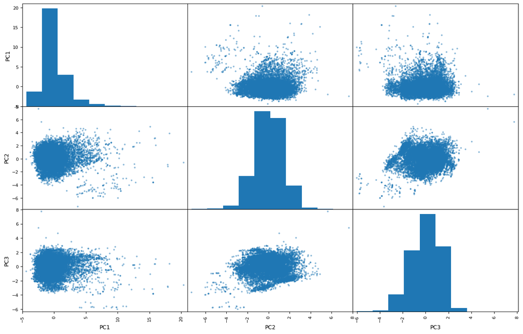

```python
pd.plotting.scatter_matrix(pca_df, figsize=(16,10))
```

### KMeans

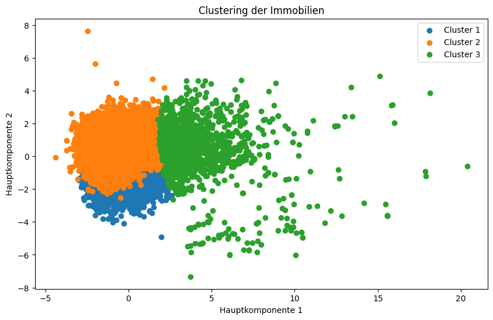

```python
# KMean trainieren auf durch den PCA erstellten Datensatz
from sklearn.cluster import KMeans

num_clusters = 3

kmeans = KMeans(n_clusters=num_clusters, random_state=42)
kmeans.fit(pca_df)

cluster_labels = kmeans.labels_

import matplotlib.pyplot as plt

plt.figure(figsize=(10, 6))
for cluster in range(num_clusters):
    plt.scatter(pca_df.loc[cluster_labels == cluster, 'PC1'],
                pca_df.loc[cluster_labels == cluster, 'PC2'],
                label=f'Cluster {cluster+1}')
plt.title('Clustering der Immobilien')
plt.xlabel('Hauptkomponente 1')
plt.ylabel('Hauptkomponente 2')
plt.legend()
plt.show()
```

- C1: Neuere Gebäude die in guter Kondition sind
- C2: Alte Gebäude, die klein sind und eine hohe Energiebilanz besitzen.
- C3: Viele alte Gebäude haben eine schlechte Erngiebilanz, große Wohnfläche und hohe Mieten. Für unseren Use Case relevant: Cluster zwei und drei vorallem Cluster drei. Diese haben hohe Mietkosten und stehen kurz vor umfassenden Renovierungen

```python
cluster_counts = {cluster+1: sum(cluster_labels == cluster) for cluster in range(num_clusters)}
print("Anzahl der Datenpunkte in jedem Cluster:", cluster_counts)
```

```
Anzahl der Datenpunkte in jedem Cluster: {1: 6123, 2: 5201, 3: 1237}
```

```python
pca_df['Cluster'] = cluster_labels

cluster_summary = pca_df.groupby('Cluster').describe()
cluster_summary
```

| Cluster | PC1 count | PC1 mean | PC1 std | PC1 min | PC1 25% | PC1 50% | PC1 75% | PC1 max | PC2 count | PC2 mean | PC2 ... | PC2 75% | PC2 max | PC3 count | PC3 mean | PC3 std | PC3 min | PC3 25% | PC3 50% | PC3 75% | PC3 max |
| --- | --- | --- | --- | --- | --- | --- | --- | --- | --- | --- | --- | --- | --- | --- | --- | --- | --- | --- | --- | --- | --- |
| 0 | 6123.0 | -0.210894 | 1.077873 | -3.065556 | -0.964679 | -0.231847 | 0.582990 | 2.620220 | 6123.0 | -0.773461 | ... | -0.066330 | 2.615523 | 6123.0 | 0.566613 | 0.895861 | -2.968278 | -0.037565 | 0.722784 | 1.194863 | 4.670670 |
| 1 | 5201.0 | -0.810741 | 1.091567 | -4.385877 | -1.593644 | -0.853897 | -0.082855 | 2.163890 | 5201.0 | 0.833418 | ... | 1.478211 | 7.643460 | 5201.0 | -0.666541 | 1.181427 | -3.741828 | -1.560159 | -0.708912 | 0.285749 | 7.743338 |
| 2 | 1237.0 | 4.452683 | 2.407120 | 1.762335 | 2.782458 | 3.785631 | 5.388148 | 20.366473 | 1237.0 | 0.324408 | ... | 1.495077 | 4.897690 | 1237.0 | -0.002176 | 1.465793 | -6.007979 | -0.748817 | 0.296888 | 1.077666 | 3.490850 |

3 rows × 24 columns

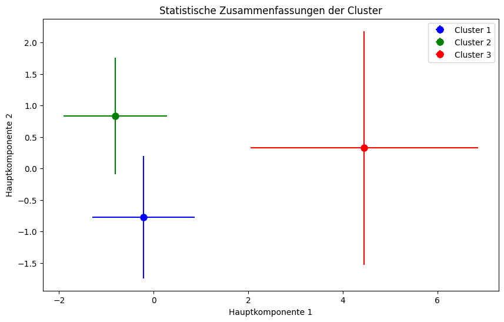

```python
# Mittelwerte der Hauptkomponenten für jedes Cluster
cluster_means = cluster_summary['PC1']['mean'], cluster_summary['PC2']['mean']
cluster_std = cluster_summary['PC1']['std'], cluster_summary['PC2']['std']
num_clusters = len(cluster_means[0])

colors = ['b', 'g', 'r', 'c', 'm']

plt.figure(figsize=(10, 6))
for i in range(num_clusters):
    plt.errorbar(cluster_means[0][i], cluster_means[1][i], xerr=cluster_std[0][i], yerr=cluster_std[1][i],
                 fmt='o', markersize=8, color=colors[i], label=f'Cluster {i+1}')

plt.title('Statistische Zusammenfassungen der Cluster')
plt.xlabel('Hauptkomponente 1')
plt.ylabel('Hauptkomponente 2')
plt.legend()
plt.show()
```

## 7. Deployment

Wir haben herausgefunden: (2.500€ Balkon renovieren, https://www.smava.de/privatkredit/balkonsanierung-kosten/#:~:text=H%C3%A4ufige%20Fragen%20zur%20Balkonsanierung,Euro%20und%205.000%20Euro%20rechnen., 20.04.2024) Dass wir 3.815 Wohnungen mit Balkon haben die renovierungsbedürftig sind. Etwa 9.5 mio €. Auch konnten wir beweisen, dass Wohnungen mit Balkon normalerweise eine höhere Rente haben, das heißt die Bewoner können sich mehr leisten.